# Heart Disease ML Pipeline

## Phase 1 — Get the Data

```python
import pandas as pd
import numpy as np
import matplotlib.pyplot as plt
import seaborn as sns

# Display settings
pd.set_option('display.max_columns', None)   # Show all columns
pd.set_option('display.float_format', '{:.2f}'.format)  # Cleaner decimals
sns.set_theme(style="whitegrid")

print("All libraries imported successfully!")
```

```
All libraries imported successfully!
```

```python
# Load the CSV file — make sure heart.csv is in the same folder as this notebook
df = pd.read_csv("heart.csv")

print(f"Dataset loaded successfully!")
print(f"Shape: {df.shape[0]} rows, {df.shape[1]} columns")
```

```
Dataset loaded successfully!
Shape: 1025 rows, 14 columns
```

```python
# Preview the first 5 rows to confirm it loaded correctly
df.head()
```

|  | age | sex | cp | trestbps | chol | fbs | restecg | thalach | exang | oldpeak | slope | ca | thal | target |
| --- | --- | --- | --- | --- | --- | --- | --- | --- | --- | --- | --- | --- | --- | --- |
| 0 | 52 | 1 | 0 | 125 | 212 | 0 | 1 | 168 | 0 | 1.00 | 2 | 2 | 3 | 0 |
| 1 | 53 | 1 | 0 | 140 | 203 | 1 | 0 | 155 | 1 | 3.10 | 0 | 0 | 3 | 0 |
| 2 | 70 | 1 | 0 | 145 | 174 | 0 | 1 | 125 | 1 | 2.60 | 0 | 0 | 3 | 0 |
| 3 | 61 | 1 | 0 | 148 | 203 | 0 | 1 | 161 | 0 | 0.00 | 2 | 1 | 3 | 0 |
| 4 | 62 | 0 | 0 | 138 | 294 | 1 | 1 | 106 | 0 | 1.90 | 1 | 3 | 2 | 0 |

```python
# Preview the last 5 rows to confirm data is consistent throughout
df.tail()
```

|  | age | sex | cp | trestbps | chol | fbs | restecg | thalach | exang | oldpeak | slope | ca | thal | target |
| --- | --- | --- | --- | --- | --- | --- | --- | --- | --- | --- | --- | --- | --- | --- |
| 1020 | 59 | 1 | 1 | 140 | 221 | 0 | 1 | 164 | 1 | 0.00 | 2 | 0 | 2 | 1 |
| 1021 | 60 | 1 | 0 | 125 | 258 | 0 | 0 | 141 | 1 | 2.80 | 1 | 1 | 3 | 0 |
| 1022 | 47 | 1 | 0 | 110 | 275 | 0 | 0 | 118 | 1 | 1.00 | 1 | 1 | 2 | 0 |
| 1023 | 50 | 0 | 0 | 110 | 254 | 0 | 0 | 159 | 0 | 0.00 | 2 | 0 | 2 | 1 |
| 1024 | 54 | 1 | 0 | 120 | 188 | 0 | 1 | 113 | 0 | 1.40 | 1 | 1 | 3 | 0 |

```python
# Check the data type of each column
print("Column Data Types:")
print("==================")
print(df.dtypes)
```

```
Column Data Types:
==================
age           int64
sex           int64
cp            int64
trestbps      int64
chol          int64
fbs           int64
restecg       int64
thalach       int64
exang         int64
oldpeak     float64
slope         int64
ca            int64
thal          int64
target        int64
dtype: object
```

```python
# See min, max, mean, std deviation for every column
print("Statistical Summary:")
print("====================")
df.describe()
```

```
Statistical Summary:
====================
```

|  | age | sex | cp | trestbps | chol | fbs | restecg | thalach | exang | oldpeak | slope | ca | thal | target |
| --- | --- | --- | --- | --- | --- | --- | --- | --- | --- | --- | --- | --- | --- | --- |
| count | 1025.00 | 1025.00 | 1025.00 | 1025.00 | 1025.00 | 1025.00 | 1025.00 | 1025.00 | 1025.00 | 1025.00 | 1025.00 | 1025.00 | 1025.00 | 1025.00 |
| mean | 54.43 | 0.70 | 0.94 | 131.61 | 246.00 | 0.15 | 0.53 | 149.11 | 0.34 | 1.07 | 1.39 | 0.75 | 2.32 | 0.51 |
| std | 9.07 | 0.46 | 1.03 | 17.52 | 51.59 | 0.36 | 0.53 | 23.01 | 0.47 | 1.18 | 0.62 | 1.03 | 0.62 | 0.50 |
| min | 29.00 | 0.00 | 0.00 | 94.00 | 126.00 | 0.00 | 0.00 | 71.00 | 0.00 | 0.00 | 0.00 | 0.00 | 0.00 | 0.00 |
| 25% | 48.00 | 0.00 | 0.00 | 120.00 | 211.00 | 0.00 | 0.00 | 132.00 | 0.00 | 0.00 | 1.00 | 0.00 | 2.00 | 0.00 |
| 50% | 56.00 | 1.00 | 1.00 | 130.00 | 240.00 | 0.00 | 1.00 | 152.00 | 0.00 | 0.80 | 1.00 | 0.00 | 2.00 | 1.00 |
| 75% | 61.00 | 1.00 | 2.00 | 140.00 | 275.00 | 0.00 | 1.00 | 166.00 | 1.00 | 1.80 | 2.00 | 1.00 | 3.00 | 1.00 |
| max | 77.00 | 1.00 | 3.00 | 200.00 | 564.00 | 1.00 | 2.00 | 202.00 | 1.00 | 6.20 | 2.00 | 4.00 | 3.00 | 1.00 |

```python
# Count missing values in each column
missing = df.isnull().sum()

print("Missing Values Per Column:")
print("===========================")
print(missing)
print(f"\nTotal missing values in entire dataset: {missing.sum()}")
```

```
Missing Values Per Column:
===========================
age         0
sex         0
cp          0
trestbps    0
chol        0
fbs         0
restecg     0
thalach     0
exang       0
oldpeak     0
slope       0
ca          0
thal        0
target      0
dtype: int64

Total missing values in entire dataset: 0
```

```python
# Count duplicate rows
duplicates = df.duplicated().sum()

print(f"Number of duplicate rows: {duplicates}")
print(f"Unique rows: {df.shape[0] - duplicates}")
```

```
Number of duplicate rows: 723
Unique rows: 302
```

```python
# See how many patients have heart disease (1) vs no disease (0)
target_counts = df['target'].value_counts()

print("Target Column Distribution:")
print("============================")
print(f"  No Heart Disease (0): {target_counts[0]} patients")
print(f"  Heart Disease    (1): {target_counts[1]} patients")
print(f"\n  Disease Rate: {target_counts[1] / len(df) * 100:.1f}%")
```

```
Target Column Distribution:
============================
  No Heart Disease (0): 499 patients
  Heart Disease    (1): 526 patients

  Disease Rate: 51.3%
```

```python
# Reference guide — what each column means
column_info = {
    "age"      : "Age of the patient (years)",
    "sex"      : "Sex — 1 = Male, 0 = Female",
    "cp"       : "Chest pain type — 0=Typical, 1=Atypical, 2=Non-anginal, 3=Asymptomatic",
    "trestbps" : "Resting blood pressure (mm Hg)",
    "chol"     : "Serum cholesterol (mg/dl)",
    "fbs"      : "Fasting blood sugar > 120 mg/dl — 1 = True, 0 = False",
    "restecg"  : "Resting ECG results — 0, 1, or 2",
    "thalach"  : "Maximum heart rate achieved (bpm)",
    "exang"    : "Exercise-induced angina — 1 = Yes, 0 = No",
    "oldpeak"  : "ST depression induced by exercise relative to rest",
    "slope"    : "Slope of peak exercise ST segment — 0, 1, or 2",
    "ca"       : "Number of major vessels coloured by fluoroscopy (0–4)",
    "thal"     : "Thalassemia — 0=Normal, 1=Fixed defect, 2=Reversible defect, 3=Unknown",
    "target"   : "Diagnosis — 1 = Heart Disease, 0 = No Heart Disease"
}

print("Column Reference Guide:")
print("========================")
for col, desc in column_info.items():
    print(f"  {col:<12} : {desc}")
```

```
Column Reference Guide:
========================
  age          : Age of the patient (years)
  sex          : Sex — 1 = Male, 0 = Female
  cp           : Chest pain type — 0=Typical, 1=Atypical, 2=Non-anginal, 3=Asymptomatic
  trestbps     : Resting blood pressure (mm Hg)
  chol         : Serum cholesterol (mg/dl)
  fbs          : Fasting blood sugar > 120 mg/dl — 1 = True, 0 = False
  restecg      : Resting ECG results — 0, 1, or 2
  thalach      : Maximum heart rate achieved (bpm)
  exang        : Exercise-induced angina — 1 = Yes, 0 = No
  oldpeak      : ST depression induced by exercise relative to rest
  slope        : Slope of peak exercise ST segment — 0, 1, or 2
  ca           : Number of major vessels coloured by fluoroscopy (0–4)
  thal         : Thalassemia — 0=Normal, 1=Fixed defect, 2=Reversible defect, 3=Unknown
  target       : Diagnosis — 1 = Heart Disease, 0 = No Heart Disease
```

## Phase 2 — Discover and Visualise the Data

In this phase we explore the dataset visually to understand patterns, relationships, and which features are most linked to heart disease.

```python
# Set consistent plot styling for all charts in this phase
plt.rcParams['figure.figsize'] = (10, 6)
plt.rcParams['axes.titlesize'] = 14
plt.rcParams['axes.titleweight'] = 'bold'
plt.rcParams['axes.labelsize'] = 12

# Colour palette — red = no disease, green = disease
COLORS = ["#E74C3C", "#2ECC71"]

print("Plot settings applied!")
```

```
Plot settings applied!
```

### Chart 1 — Target Distribution

How many patients have heart disease vs no heart disease?

[figure not shown]

```
No Heart Disease : 499 patients (48.7%)
Heart Disease    : 526 patients (51.3%)
The dataset is well balanced — no resampling needed.
```

```python
fig, ax = plt.subplots(figsize=(7, 5))

counts = df['target'].value_counts()
labels = ['No Heart Disease', 'Heart Disease']
bars = ax.bar(labels, counts.values, color=COLORS, edgecolor='white', linewidth=1.5, width=0.5)

# Add count labels on top of each bar
for bar, val in zip(bars, counts.values):
    ax.text(
        bar.get_x() + bar.get_width() / 2,
        bar.get_height() + 5,
        f"{val} ({val/len(df)*100:.1f}%)",
        ha='center', fontsize=12, fontweight='bold'
    )

ax.set_title("Target Distribution — Heart Disease vs No Disease")
ax.set_ylabel("Number of Patients")
ax.set_ylim(0, max(counts.values) + 60)
sns.despine()
plt.tight_layout()
plt.show()

print(f"No Heart Disease : {counts[0]} patients ({counts[0]/len(df)*100:.1f}%)")
print(f"Heart Disease    : {counts[1]} patients ({counts[1]/len(df)*100:.1f}%)")
print("The dataset is well balanced — no resampling needed.")
```

### Chart 2 — Age Distribution by Target

Which age groups are most affected by heart disease?

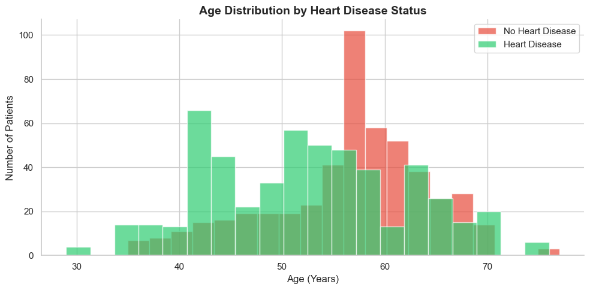

```
Age Statistics:
================

  No Heart Disease:
    Mean age : 56.6 years
    Min age  : 35 years
    Max age  : 77 years

  Heart Disease:
    Mean age : 52.4 years
    Min age  : 29 years
    Max age  : 76 years
```

```python
fig, ax = plt.subplots(figsize=(10, 5))

for target, label, color in zip([0, 1], ['No Heart Disease', 'Heart Disease'], COLORS):
    ax.hist(
        df[df['target'] == target]['age'],
        bins=20, alpha=0.7, color=color,
        label=label, edgecolor='white'
    )

ax.set_title("Age Distribution by Heart Disease Status")
ax.set_xlabel("Age (Years)")
ax.set_ylabel("Number of Patients")
ax.legend(fontsize=11)
sns.despine()
plt.tight_layout()
plt.show()

# Print age statistics by group
print("Age Statistics:")
print("================")
for target, label in zip([0, 1], ['No Heart Disease', 'Heart Disease']):
    ages = df[df['target'] == target]['age']
    print(f"\n  {label}:")
    print(f"    Mean age : {ages.mean():.1f} years")
    print(f"    Min age  : {ages.min()} years")
    print(f"    Max age  : {ages.max()} years")
```

### Chart 3 — Sex vs Heart Disease

Are males or females more likely to have heart disease in this dataset?

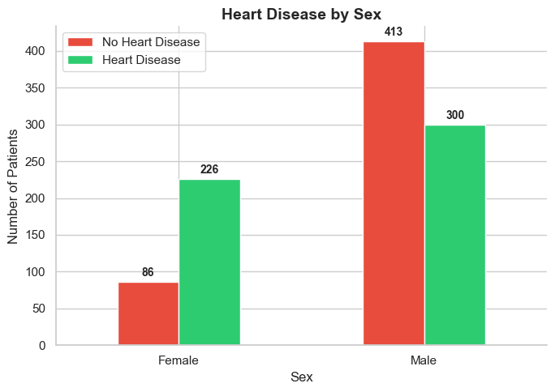

```
Disease Rate by Sex:
=====================
  Female: 72.4% have heart disease (226 out of 312)
  Male: 42.1% have heart disease (300 out of 713)
```

```python
fig, ax = plt.subplots(figsize=(7, 5))

sex_target = df.groupby(['sex', 'target']).size().unstack()
sex_target.index = ['Female', 'Male']
sex_target.columns = ['No Heart Disease', 'Heart Disease']
sex_target.plot(kind='bar', ax=ax, color=COLORS, edgecolor='white', width=0.5)

# Add count labels on each bar segment
for container in ax.containers:
    ax.bar_label(container, fontsize=10, fontweight='bold', padding=3)

ax.set_title("Heart Disease by Sex")
ax.set_xlabel("Sex")
ax.set_ylabel("Number of Patients")
ax.set_xticklabels(['Female', 'Male'], rotation=0)
ax.legend(fontsize=11)
sns.despine()
plt.tight_layout()
plt.show()

# Print disease rate per sex
print("Disease Rate by Sex:")
print("=====================")
for sex, label in zip([0, 1], ['Female', 'Male']):
    group = df[df['sex'] == sex]
    rate = group['target'].mean() * 100
    print(f"  {label}: {rate:.1f}% have heart disease ({group['target'].sum()} out of {len(group)})")
```

### Chart 4 — Chest Pain Type vs Heart Disease

Chest pain type (cp) is one of the strongest predictors — let's see why.

- **0** = Typical angina
- **1** = Atypical angina
- **2** = Non-anginal pain
- **3** = Asymptomatic

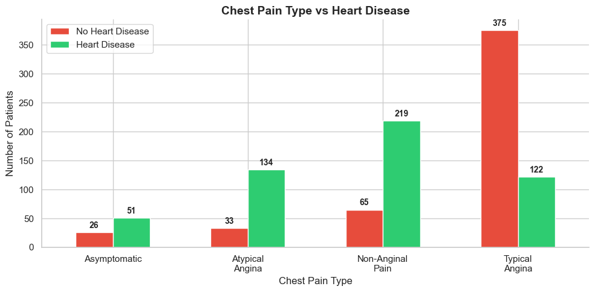

```python
fig, ax = plt.subplots(figsize=(10, 5))

cp_labels = {0: 'Typical\nAngina', 1: 'Atypical\nAngina', 2: 'Non-Anginal\nPain', 3: 'Asymptomatic'}
df['cp_label'] = df['cp'].map(cp_labels)

cp_target = df.groupby(['cp_label', 'target']).size().unstack().fillna(0)
cp_target.columns = ['No Heart Disease', 'Heart Disease']
cp_target.plot(kind='bar', ax=ax, color=COLORS, edgecolor='white', width=0.55)

for container in ax.containers:
    ax.bar_label(container, fontsize=10, fontweight='bold', padding=3)

ax.set_title("Chest Pain Type vs Heart Disease")
ax.set_xlabel("Chest Pain Type")
ax.set_ylabel("Number of Patients")
ax.set_xticklabels(cp_target.index, rotation=0)
ax.legend(fontsize=11)
sns.despine()
plt.tight_layout()
plt.show()

# Clean up the temporary column
df.drop(columns=['cp_label'], inplace=True)
```

### Chart 5 — Maximum Heart Rate (thalach) by Target

Patients with heart disease tend to achieve a higher maximum heart rate during exercise.

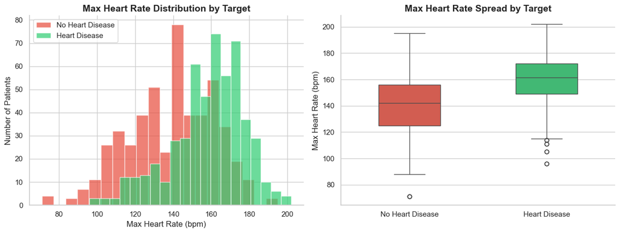

```
Max Heart Rate Statistics:
===========================

  No Heart Disease:
    Mean  : 139.1 bpm
    Median: 142.0 bpm

  Heart Disease:
    Mean  : 158.6 bpm
    Median: 161.5 bpm
```

```python
fig, axes = plt.subplots(1, 2, figsize=(13, 5))

# Left: Histogram
for target, label, color in zip([0, 1], ['No Heart Disease', 'Heart Disease'], COLORS):
    axes[0].hist(
        df[df['target'] == target]['thalach'],
        bins=20, alpha=0.7, color=color,
        label=label, edgecolor='white'
    )
axes[0].set_title("Max Heart Rate Distribution by Target")
axes[0].set_xlabel("Max Heart Rate (bpm)")
axes[0].set_ylabel("Number of Patients")
axes[0].legend(fontsize=11)
sns.despine(ax=axes[0])

# Right: Boxplot — hue fixes the palette deprecation warning
sns.boxplot(
    x='target', y='thalach', data=df,
    hue='target', palette={0: "#E74C3C", 1: "#2ECC71"},
    ax=axes[1], width=0.45, legend=False
)
axes[1].set_xticks([0, 1])
axes[1].set_xticklabels(['No Heart Disease', 'Heart Disease'])
axes[1].set_title("Max Heart Rate Spread by Target")
axes[1].set_xlabel("")
axes[1].set_ylabel("Max Heart Rate (bpm)")
sns.despine(ax=axes[1])

plt.tight_layout()
plt.show()

print("Max Heart Rate Statistics:")
print("===========================")
for target, label in zip([0, 1], ['No Heart Disease', 'Heart Disease']):
    vals = df[df['target'] == target]['thalach']
    print(f"\n  {label}:")
    print(f"    Mean  : {vals.mean():.1f} bpm")
    print(f"    Median: {vals.median():.1f} bpm")
```

### Chart 6 — ST Depression (oldpeak) by Target

ST depression measures electrical changes during exercise. Higher values suggest reduced blood flow to the heart.

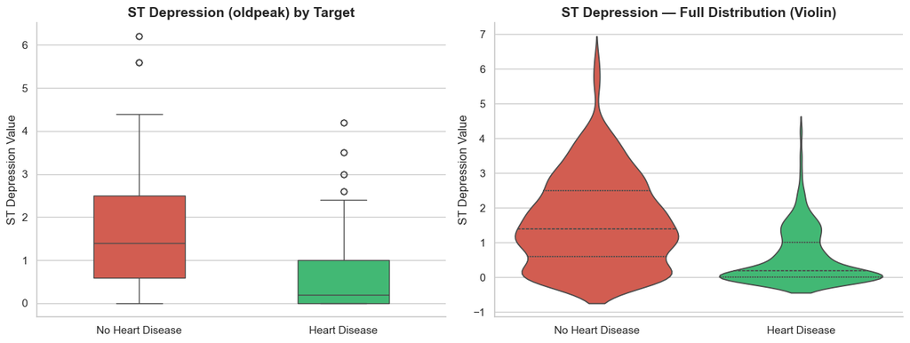

```
ST Depression (oldpeak) Statistics:
=====================================

  No Heart Disease:
    Mean   : 1.60
    Median : 1.40
    Max    : 6.20

  Heart Disease:
    Mean   : 0.57
    Median : 0.20
    Max    : 4.20

  No Heart Disease:
    Mean   : 1.60
    Median : 1.40
    Max    : 6.20

  Heart Disease:
    Mean   : 0.57
    Median : 0.20
    Max    : 4.20
```

```python
fig, axes = plt.subplots(1, 2, figsize=(13, 5))

# Left: Boxplot
sns.boxplot(
    x='target', y='oldpeak', data=df,
    hue='target', palette={0: "#E74C3C", 1: "#2ECC71"},
    ax=axes[0], width=0.45, legend=False
)
axes[0].set_xticks([0, 1])
axes[0].set_xticklabels(['No Heart Disease', 'Heart Disease'])
axes[0].set_title("ST Depression (oldpeak) by Target")
axes[0].set_xlabel("")
axes[0].set_ylabel("ST Depression Value")
sns.despine(ax=axes[0])

# Right: Violin plot
sns.violinplot(
    x='target', y='oldpeak', data=df,
    hue='target', palette={0: "#E74C3C", 1: "#2ECC71"},
    ax=axes[1], inner='quartile', legend=False
)
axes[1].set_xticks([0, 1])
axes[1].set_xticklabels(['No Heart Disease', 'Heart Disease'])
axes[1].set_title("ST Depression — Full Distribution (Violin)")
axes[1].set_xlabel("")
axes[1].set_ylabel("ST Depression Value")
sns.despine(ax=axes[1])

plt.tight_layout()
plt.show()

print("ST Depression (oldpeak) Statistics:")
print("=====================================")
for target, label in zip([0, 1], ['No Heart Disease', 'Heart Disease']):
    vals = df[df['target'] == target]['oldpeak']
    print(f"\n  {label}:")
    print(f"    Mean   : {vals.mean():.2f}")
    print(f"    Median : {vals.median():.2f}")
    print(f"    Max    : {vals.max():.2f}")
for target, label in zip([0, 1], ['No Heart Disease', 'Heart Disease']):
    vals = df[df['target'] == target]['oldpeak']
    print(f"\n  {label}:")
    print(f"    Mean   : {vals.mean():.2f}")
    print(f"    Median : {vals.median():.2f}")
    print(f"    Max    : {vals.max():.2f}")
```

### Chart 7 — Cholesterol vs Age (Scatter)

Do older patients with higher cholesterol tend to have heart disease?

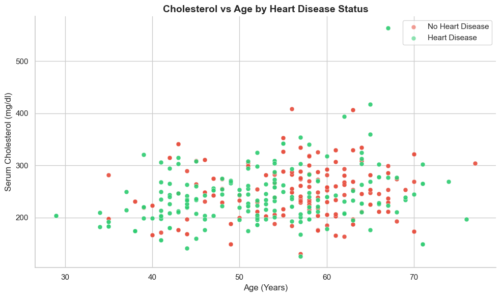

```
Cholesterol Statistics:
========================

  No Heart Disease:
    Mean   : 251.3 mg/dl
    Median : 249.0 mg/dl
    Max    : 409.0 mg/dl

  Heart Disease:
    Mean   : 241.0 mg/dl
    Median : 234.0 mg/dl
    Max    : 564.0 mg/dl
```

```python
fig, ax = plt.subplots(figsize=(10, 6))

for target, label, color in zip([0, 1], ['No Heart Disease', 'Heart Disease'], COLORS):
    subset = df[df['target'] == target]
    ax.scatter(
        subset['age'], subset['chol'],
        alpha=0.55, s=40, color=color,
        label=label, edgecolors='white', linewidth=0.4
    )

ax.set_title("Cholesterol vs Age by Heart Disease Status")
ax.set_xlabel("Age (Years)")
ax.set_ylabel("Serum Cholesterol (mg/dl)")
ax.legend(fontsize=11)
sns.despine()
plt.tight_layout()
plt.show()

print("Cholesterol Statistics:")
print("========================")
for target, label in zip([0, 1], ['No Heart Disease', 'Heart Disease']):
    vals = df[df['target'] == target]['chol']
    print(f"\n  {label}:")
    print(f"    Mean   : {vals.mean():.1f} mg/dl")
    print(f"    Median : {vals.median():.1f} mg/dl")
    print(f"    Max    : {vals.max():.1f} mg/dl")
```

### Chart 8 — Feature Correlation Matrix

Which features are most strongly correlated with the target (heart disease)? Values close to +1 or -1 are the most important predictors.

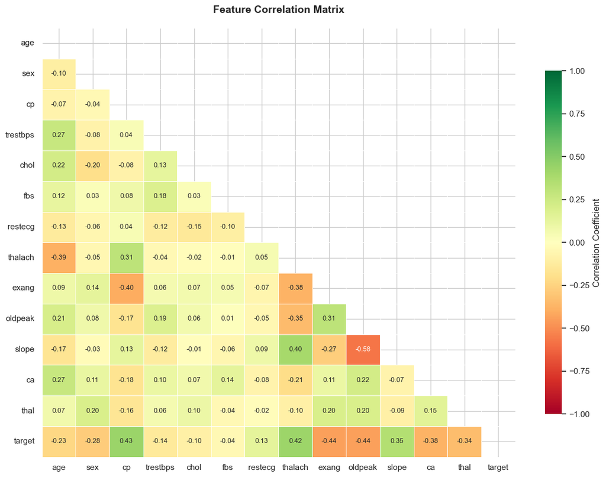

```
Top Feature Correlations with Target (Heart Disease):
=======================================================
  oldpeak      : -0.438  (negative)
  exang        : -0.438  (negative)
  cp           : +0.435  (positive)
  thalach      : +0.423  (positive)
  ca           : -0.382  (negative)
  slope        : +0.346  (positive)
  thal         : -0.338  (negative)
  sex          : -0.280  (negative)
  age          : -0.229  (negative)
  trestbps     : -0.139  (negative)
  restecg      : +0.134  (positive)
  chol         : -0.100  (negative)
  fbs          : -0.041  (negative)
```

```python
fig, ax = plt.subplots(figsize=(12, 9))

corr_matrix = df.corr(numeric_only=True)

mask = np.triu(np.ones_like(corr_matrix, dtype=bool))

sns.heatmap(
    corr_matrix,
    mask=mask,
    annot=True,
    fmt='.2f',
    cmap='RdYlGn',
    ax=ax,
    linewidths=0.5,
    linecolor='white',
    annot_kws={'size': 9},
    vmin=-1, vmax=1,
    cbar_kws={'shrink': 0.8, 'label': 'Correlation Coefficient'}
)

ax.set_title("Feature Correlation Matrix", pad=20)
plt.tight_layout()
plt.show()

print("Top Feature Correlations with Target (Heart Disease):")
print("=======================================================")
target_corr = corr_matrix['target'].drop('target').sort_values(key=abs, ascending=False)
for feature, corr_val in target_corr.items():
    direction = "positive" if corr_val > 0 else "negative"
    print(f"  {feature:<12} : {corr_val:+.3f}  ({direction})")
```

### Chart 9 — Pairplot of Top Features

A pairplot of the most correlated features coloured by target — useful for spotting clusters and separability between the two classes.

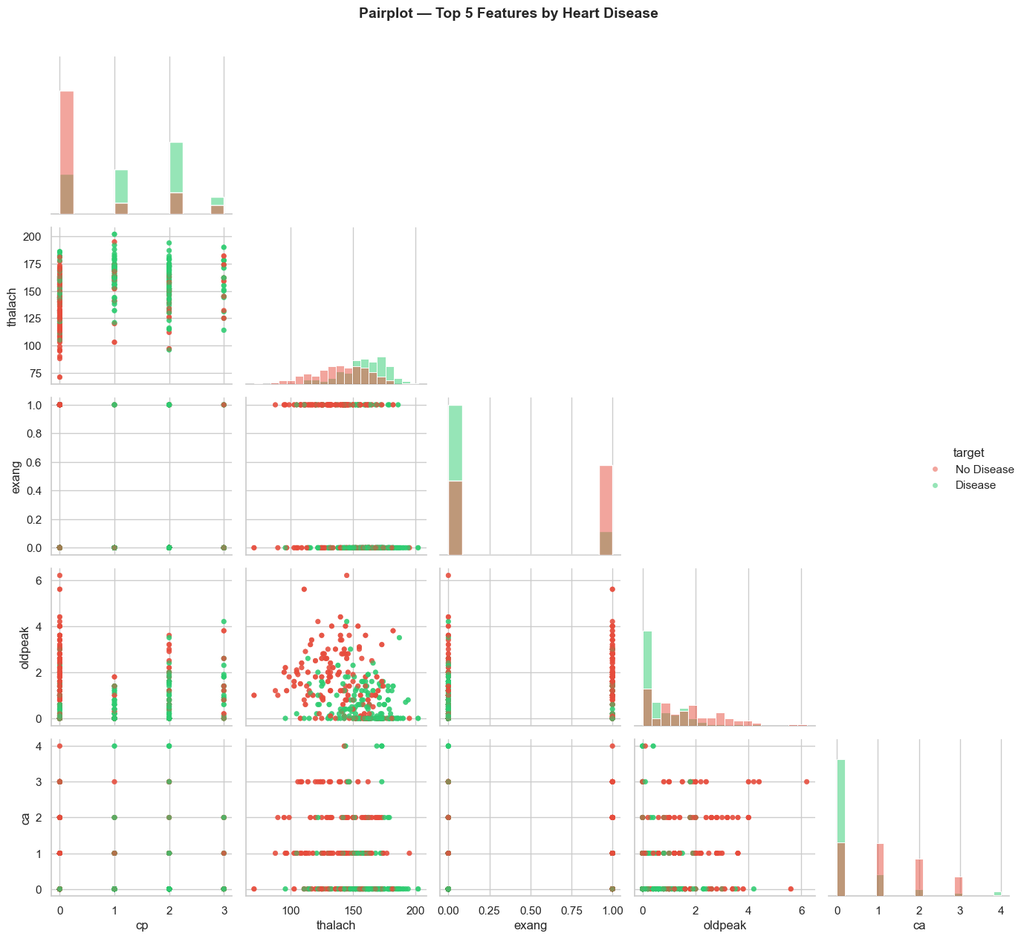

```python
top_features = ['cp', 'thalach', 'exang', 'oldpeak', 'ca', 'target']

pair_df = df[top_features].copy()
pair_df['target'] = pair_df['target'].map({0: 'No Disease', 1: 'Disease'})

g = sns.pairplot(
    pair_df,
    hue='target',
    palette={'No Disease': '#E74C3C', 'Disease': '#2ECC71'},
    plot_kws={'alpha': 0.5, 's': 25, 'edgecolor': 'none'},
    diag_kind='hist',
    corner=True
)

g.figure.suptitle(
    "Pairplot — Top 5 Features by Heart Disease",
    y=1.01, fontsize=14, fontweight='bold'
)
plt.tight_layout()
plt.show()
```

### Chart 10 — All Feature Distributions by Target

A complete overview of every feature split by heart disease status.

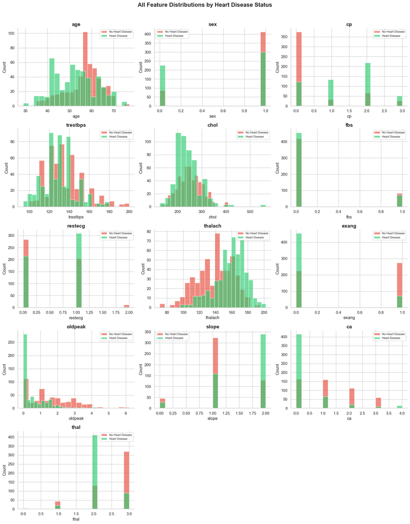

```python
features = [col for col in df.columns if col != 'target']
n_cols = 3
n_rows = (len(features) + n_cols - 1) // n_cols

fig, axes = plt.subplots(n_rows, n_cols, figsize=(16, n_rows * 4))
axes = axes.flatten()

for i, feature in enumerate(features):
    for target, label, color in zip([0, 1], ['No Heart Disease', 'Heart Disease'], COLORS):
        axes[i].hist(
            df[df['target'] == target][feature],
            bins=20, alpha=0.65, color=color,
            label=label, edgecolor='white'
        )
    axes[i].set_title(feature, fontweight='bold')
    axes[i].set_xlabel(feature)
    axes[i].set_ylabel("Count")
    axes[i].legend(fontsize=8)
    sns.despine(ax=axes[i])

for j in range(i + 1, len(axes)):
    axes[j].set_visible(False)

fig.suptitle(
    "All Feature Distributions by Heart Disease Status",
    fontsize=16, fontweight='bold', y=1.01
)
plt.tight_layout()
plt.show()
```

## Phase 3 — Prepare the Data for Machine Learning

In this phase we clean the data, remove duplicates, split into train/test sets, and set up our scaling pipeline ready for model training in Phase 4.

### Step 1 — Remove Duplicate Rows

The original dataset has 1,025 rows but contains 723 duplicate entries. Duplicates must be removed because:

- They give the model a false sense of confidence by seeing the same data point multiple times
- They can cause data leakage if the same row ends up in both the training set and the test set
- They inflate performance metrics and make the model look better than it actually is

After removing duplicates we will be left with **302 unique patient records.**

```python
print("Dataset shape BEFORE cleaning:")
print("================================")
print(f"  Rows    : {df.shape[0]}")
print(f"  Columns : {df.shape[1]}")
print(f"\nDuplicate rows found: {df.duplicated().sum()}")
```

```
Dataset shape BEFORE cleaning:
================================
  Rows    : 1025
  Columns : 14

Duplicate rows found: 723
```

```python
# Remove all duplicate rows
df.drop_duplicates(inplace=True)

# Reset the index after dropping rows
df.reset_index(drop=True, inplace=True)

print("Duplicates removed successfully!")
print("\nDataset shape AFTER cleaning:")
print("================================")
print(f"  Rows    : {df.shape[0]}")
print(f"  Columns : {df.shape[1]}")
print(f"\nDuplicate rows remaining: {df.duplicated().sum()}")
```

```
Duplicates removed successfully!

Dataset shape AFTER cleaning:
================================
  Rows    : 302
  Columns : 14

Duplicate rows remaining: 0
```

```python
print("Missing values after cleaning:")
print("================================")
missing = df.isnull().sum()
print(missing)
print(f"\nTotal missing values: {missing.sum()}")

if missing.sum() == 0:
    print("\nNo missing values — dataset is clean and ready!")
```

```
Missing values after cleaning:
================================
age         0
sex         0
cp          0
trestbps    0
chol        0
fbs         0
restecg     0
thalach     0
exang       0
oldpeak     0
slope       0
ca          0
thal        0
target      0
dtype: int64

Total missing values: 0

No missing values — dataset is clean and ready!
```

```python
target_counts = df['target'].value_counts()

print("Target distribution after cleaning:")
print("=====================================")
print(f"  No Heart Disease (0) : {target_counts[0]} patients ({target_counts[0]/len(df)*100:.1f}%)")
print(f"  Heart Disease    (1) : {target_counts[1]} patients ({target_counts[1]/len(df)*100:.1f}%)")
print("\nDataset is still balanced — no resampling required.")
```

```
Target distribution after cleaning:
=====================================
  No Heart Disease (0) : 138 patients (45.7%)
  Heart Disease    (1) : 164 patients (54.3%)

Dataset is still balanced — no resampling required.
```

### Step 2 — Separate Features (X) and Target (y)

- **X** contains all input features the model will learn from
- **y** contains the target column (0 or 1) the model will predict

```python
# X = all columns except target
X = df.drop('target', axis=1)

# y = target column only
y = df['target']

print("Features (X):")
print("==============")
print(f"  Shape   : {X.shape}")
print(f"  Columns : {list(X.columns)}")

print("\nTarget (y):")
print("============")
print(f"  Shape          : {y.shape}")
print(f"  Unique values  : {sorted(y.unique())}")
print(f"  Value counts   :\n{y.value_counts()}")
```

```
Features (X):
==============
  Shape   : (302, 13)
  Columns : ['age', 'sex', 'cp', 'trestbps', 'chol', 'fbs', 'restecg', 'thalach', 'exang', 'oldpeak', 'slope', 'ca', 'thal']

Target (y):
============
  Shape          : (302,)
  Unique values  : [np.int64(0), np.int64(1)]
  Value counts   :
target
1    164
0    138
Name: count, dtype: int64
```

### Step 3 — Split into Training and Test Sets

We use an **80/20 split**:

- **80% training** — the model learns from this data
- **20% test** — held back completely to evaluate final performance

We use `stratify=y` to ensure both splits have the same ratio of disease to no-disease, which is important for balanced evaluation.

We use `random_state=42` so the split is reproducible every time you run the notebook.

```python
from sklearn.model_selection import train_test_split

X_train, X_test, y_train, y_test = train_test_split(
    X, y,
    test_size=0.2,       # 20% goes to test set
    random_state=42,     # reproducible split
    stratify=y           # preserve class balance in both splits
)

print("Train/Test Split Complete!")
print("===========================")
print(f"  Training set   : {X_train.shape[0]} rows  ({X_train.shape[0]/len(df)*100:.1f}%)")
print(f"  Test set       : {X_test.shape[0]} rows  ({X_test.shape[0]/len(df)*100:.1f}%)")
print(f"  Features       : {X_train.shape[1]} columns")
```

```
Train/Test Split Complete!
===========================
  Training set   : 241 rows  (79.8%)
  Test set       : 61 rows  (20.2%)
  Features       : 13 columns
```

```python
print("Class balance verification:")
print("============================")

train_counts = y_train.value_counts()
test_counts  = y_test.value_counts()

print(f"\n  Training set:")
print(f"    No Disease (0) : {train_counts[0]}  ({train_counts[0]/len(y_train)*100:.1f}%)")
print(f"    Disease    (1) : {train_counts[1]}  ({train_counts[1]/len(y_train)*100:.1f}%)")

print(f"\n  Test set:")
print(f"    No Disease (0) : {test_counts[0]}  ({test_counts[0]/len(y_test)*100:.1f}%)")
print(f"    Disease    (1) : {test_counts[1]}  ({test_counts[1]/len(y_test)*100:.1f}%)")

print("\nBoth splits have a similar class ratio — stratification worked correctly!")
```

```
Class balance verification:
============================

  Training set:
    No Disease (0) : 110  (45.6%)
    Disease    (1) : 131  (54.4%)

  Test set:
    No Disease (0) : 28  (45.9%)
    Disease    (1) : 33  (54.1%)

Both splits have a similar class ratio — stratification worked correctly!
```

[figure not shown]

```python
fig, axes = plt.subplots(1, 3, figsize=(14, 5))

datasets  = [y, y_train, y_test]
titles    = ['Full Dataset\n(302 rows)', 'Training Set\n(241 rows)', 'Test Set\n(61 rows)']

for ax, data, title in zip(axes, datasets, titles):
    counts = data.value_counts()
    bars = ax.bar(
        ['No Disease', 'Disease'],
        counts.values,
        color=COLORS, edgecolor='white', linewidth=1.5, width=0.5
    )
    for bar, val in zip(bars, counts.values):
        ax.text(
            bar.get_x() + bar.get_width() / 2,
            bar.get_height() + 1,
            f"{val}\n({val/len(data)*100:.1f}%)",
            ha='center', fontsize=10, fontweight='bold'
        )
    ax.set_title(title, fontweight='bold')
    ax.set_ylabel("Number of Patients")
    ax.set_ylim(0, max(counts.values) + 25)
    sns.despine(ax=ax)

fig.suptitle("Class Balance Across Full Dataset, Train, and Test Sets",
             fontsize=13, fontweight='bold', y=1.02)
plt.tight_layout()
plt.show()
```

### Step 4 — Feature Scaling with StandardScaler

Many ML algorithms (Logistic Regression, SVM) are sensitive to the scale of features. For example:

- `age` ranges from 29 to 77
- `chol` ranges from 126 to 564
- `oldpeak` ranges from 0 to 6.2

Without scaling, the model may treat `chol` as more important simply because its numbers are larger — even if it is actually a weaker predictor.

**StandardScaler** transforms each feature so it has:

- Mean = 0
- Standard deviation = 1

**Important:** We do NOT fit the scaler on the test set. We will fit it only on training data inside a **Pipeline** in Phase 4. This prevents **data leakage** — where information from the test set accidentally influences the model during training.

```python
print("Feature value ranges BEFORE scaling:")
print("======================================")
print(f"  {'Feature':<12}  {'Min':>8}  {'Max':>8}  {'Mean':>8}  {'Std':>8}")
print(f"  {'-'*12}  {'-'*8}  {'-'*8}  {'-'*8}  {'-'*8}")

for col in X_train.columns:
    print(f"  {col:<12}  "
          f"{X_train[col].min():>8.2f}  "
          f"{X_train[col].max():>8.2f}  "
          f"{X_train[col].mean():>8.2f}  "
          f"{X_train[col].std():>8.2f}")
```

```
Feature value ranges BEFORE scaling:
======================================
  Feature            Min       Max      Mean       Std
  ------------  --------  --------  --------  --------
  age              29.00     77.00     54.20      9.02
  sex               0.00      1.00      0.68      0.47
  cp                0.00      3.00      0.98      1.03
  trestbps         94.00    192.00    131.32     16.80
  chol            126.00    564.00    247.63     53.89
  fbs               0.00      1.00      0.14      0.34
  restecg           0.00      2.00      0.54      0.53
  thalach          71.00    202.00    150.83     22.52
  exang             0.00      1.00      0.30      0.46
  oldpeak           0.00      6.20      1.00      1.15
  slope             0.00      2.00      1.42      0.61
  ca                0.00      4.00      0.76      1.05
  thal              0.00      3.00      2.34      0.62
```

### Step 5 — Build the Sklearn Pipeline

A **Pipeline** chains the scaler and model together into one object.

Benefits:

- Scaler is always fitted on training data only — no leakage
- You call `.fit()` and `.predict()` once on the whole pipeline
- Works correctly inside cross-validation and GridSearchCV
- Easy to save and deploy as a single object

We will define the pipelines in Phase 4 when we attach models to them. Here we confirm the pipeline import is working correctly.

```python
from sklearn.preprocessing import StandardScaler
from sklearn.pipeline import Pipeline
from sklearn.linear_model import LogisticRegression
from sklearn.ensemble import RandomForestClassifier, GradientBoostingClassifier
from sklearn.svm import SVC
from sklearn.model_selection import cross_val_score, StratifiedKFold
from sklearn.metrics import (
    accuracy_score, precision_score, recall_score,
    f1_score, confusion_matrix, classification_report,
    roc_curve, auc
)
import joblib

print("All Phase 4 libraries imported successfully!")
print("\nReady to build pipelines in Phase 4.")
```

```
All Phase 4 libraries imported successfully!

Ready to build pipelines in Phase 4.
```

```python
# This cell is for DEMONSTRATION only — to show what scaling does to the values
# The actual scaler will be fitted inside a Pipeline in Phase 4

from sklearn.preprocessing import StandardScaler

demo_scaler = StandardScaler()
X_train_scaled_demo = demo_scaler.fit_transform(X_train)
X_train_scaled_df   = pd.DataFrame(X_train_scaled_demo, columns=X_train.columns)

print("Feature value ranges AFTER scaling (demonstration):")
print("======================================================")
print(f"  {'Feature':<12}  {'Min':>8}  {'Max':>8}  {'Mean':>8}  {'Std':>8}")
print(f"  {'-'*12}  {'-'*8}  {'-'*8}  {'-'*8}  {'-'*8}")

for col in X_train_scaled_df.columns:
    print(f"  {col:<12}  "
          f"{X_train_scaled_df[col].min():>8.2f}  "
          f"{X_train_scaled_df[col].max():>8.2f}  "
          f"{X_train_scaled_df[col].mean():>8.2f}  "
          f"{X_train_scaled_df[col].std():>8.2f}")

print("\nAll features now have Mean ≈ 0 and Std ≈ 1")
print("Note: This demo scaler is NOT used in Phase 4 — scaling happens inside the Pipeline.")
```

```
Feature value ranges AFTER scaling (demonstration):
======================================================
  Feature            Min       Max      Mean       Std
  ------------  --------  --------  --------  --------
  age              -2.80      2.53     -0.00      1.00
  sex              -1.45      0.69     -0.00      1.00
  cp               -0.95      1.96      0.00      1.00
  trestbps         -2.23      3.62     -0.00      1.00
  chol             -2.26      5.88      0.00      1.00
  fbs              -0.40      2.51     -0.00      1.00
  restecg          -1.01      2.76     -0.00      1.00
  thalach          -3.55      2.28      0.00      1.00
  exang            -0.65      1.53     -0.00      1.00
  oldpeak          -0.87      4.54     -0.00      1.00
  slope            -2.34      0.95     -0.00      1.00
  ca               -0.72      3.08      0.00      1.00
  thal             -3.79      1.08     -0.00      1.00

All features now have Mean ≈ 0 and Std ≈ 1
Note: This demo scaler is NOT used in Phase 4 — scaling happens inside the Pipeline.
```

## Phase 4 — Select and Train a Model

In this phase we build 4 different models, evaluate each one using 5-fold cross validation, compare their performance, and select the best one to carry forward into Phase 5 for fine-tuning.

### Step 1 — Build Model Pipelines

Each pipeline contains two steps:

1. **StandardScaler** — scales the features (fitted on training data only)
2. **Classifier** — the model that learns the patterns

Using a pipeline ensures the scaler never sees the test data during training, which prevents data leakage.

The 4 models we will compare:

- **Logistic Regression** — simple, fast, good baseline
- **Random Forest** — ensemble of decision trees, handles non-linear patterns
- **Gradient Boosting** — builds trees sequentially, often very accurate
- **SVM** — finds the optimal boundary between classes

```python
# Build a pipeline for each model
models = {
    "Logistic Regression" : Pipeline([
        ('scaler', StandardScaler()),
        ('clf',    LogisticRegression(random_state=42, max_iter=1000))
    ]),
    "Random Forest" : Pipeline([
        ('scaler', StandardScaler()),
        ('clf',    RandomForestClassifier(random_state=42, n_estimators=100))
    ]),
    "Gradient Boosting" : Pipeline([
        ('scaler', StandardScaler()),
        ('clf',    GradientBoostingClassifier(random_state=42))
    ]),
    "SVM" : Pipeline([
        ('scaler', StandardScaler()),
        ('clf',    SVC(probability=True, random_state=42))
    ])
}

print("Pipelines built successfully!")
print("================================")
for name in models:
    print(f"  {name}")
```

```
Pipelines built successfully!
================================
  Logistic Regression
  Random Forest
  Gradient Boosting
  SVM
```

### Step 2 — Cross Validation Setup

We use **5-Fold Stratified Cross Validation** to evaluate each model fairly.

How it works:

1. The training set is split into 5 equal folds
2. The model trains on 4 folds and is tested on the remaining 1 fold
3. This repeats 5 times — each fold gets a turn as the test fold
4. The 5 accuracy scores are averaged to give a reliable estimate

This gives a much more reliable score than a single train/test split because every data point gets evaluated exactly once.

`StratifiedKFold` ensures each fold has the same class balance.

```python
# Set up stratified 5-fold cross validation
cv = StratifiedKFold(n_splits=5, shuffle=True, random_state=42)

# Store results for comparison
cv_results = {}

print("Running 5-Fold Cross Validation on all models...")
print("==================================================")

for name, pipeline in models.items():
    scores = cross_val_score(
        pipeline, X_train, y_train,
        cv=cv, scoring='accuracy'
    )
    cv_results[name] = {
        'scores' : scores,
        'mean'   : scores.mean(),
        'std'    : scores.std()
    }
    print(f"\n  {name}:")
    print(f"    Fold scores : {[f'{s:.4f}' for s in scores]}")
    print(f"    Mean        : {scores.mean():.4f}")
    print(f"    Std Dev     : {scores.std():.4f}")

print("\nCross validation complete!")
```

```
Running 5-Fold Cross Validation on all models...
==================================================

  Logistic Regression:
    Fold scores : ['0.8980', '0.7917', '0.8333', '0.9583', '0.7083']
    Mean        : 0.8379
    Std Dev     : 0.0861

  Random Forest:
    Fold scores : ['0.8980', '0.8333', '0.8125', '0.8958', '0.8125']
    Mean        : 0.8504
    Std Dev     : 0.0387

  Gradient Boosting:
    Fold scores : ['0.8163', '0.8542', '0.8125', '0.8750', '0.7708']
    Mean        : 0.8258
    Std Dev     : 0.0361

  SVM:
    Fold scores : ['0.8980', '0.8333', '0.8750', '0.8750', '0.7708']
    Mean        : 0.8504
    Std Dev     : 0.0449

Cross validation complete!
```

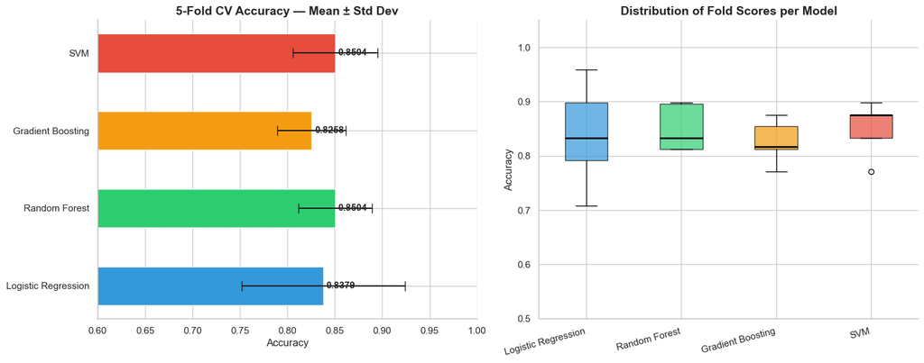

```python
fig, axes = plt.subplots(1, 2, figsize=(15, 6))

names  = list(cv_results.keys())
means  = [cv_results[n]['mean'] for n in names]
stds   = [cv_results[n]['std']  for n in names]
colors_cv = ['#3498DB', '#2ECC71', '#F39C12', '#E74C3C']

# Left: Horizontal bar chart with error bars
bars = axes[0].barh(
    names, means, xerr=stds,
    color=colors_cv, edgecolor='white',
    height=0.5, capsize=6
)
axes[0].set_xlim(0.6, 1.0)
axes[0].set_title("5-Fold CV Accuracy — Mean ± Std Dev", fontweight='bold')
axes[0].set_xlabel("Accuracy")

for bar, mean in zip(bars, means):
    axes[0].text(
        mean + 0.003,
        bar.get_y() + bar.get_height() / 2,
        f"{mean:.4f}",
        va='center', fontsize=11, fontweight='bold'
    )
sns.despine(ax=axes[0])

# Right: Box plot — renamed 'labels' to 'tick_labels' (Matplotlib 3.9+)
fold_data = [cv_results[n]['scores'] for n in names]
bp = axes[1].boxplot(
    fold_data, tick_labels=names, patch_artist=True,
    medianprops=dict(color='black', linewidth=2)
)
for patch, color in zip(bp['boxes'], colors_cv):
    patch.set_facecolor(color)
    patch.set_alpha(0.7)

axes[1].set_title("Distribution of Fold Scores per Model", fontweight='bold')
axes[1].set_ylabel("Accuracy")
axes[1].set_ylim(0.5, 1.05)
axes[1].set_xticklabels(names, rotation=15, ha='right')
sns.despine(ax=axes[1])

plt.tight_layout()
plt.show()
```

### Step 3 — Train on Full Training Set and Evaluate on Test Set

After cross validation we now train each model on the **entire training set** and evaluate it on the **held-out test set** to get final performance metrics:

- **Accuracy** — percentage of correct predictions overall
- **Precision** — of all predicted disease cases, how many were actually disease
- **Recall** — of all actual disease cases, how many did the model catch
- **F1 Score** — harmonic mean of precision and recall (best single metric for classification)

```python
test_results = {}

print("Training all models on full training set...")
print("=============================================")

for name, pipeline in models.items():
    # Train on full training set
    pipeline.fit(X_train, y_train)

    # Predict on test set
    y_pred = pipeline.predict(X_test)

    # Calculate metrics
    test_results[name] = {
        'accuracy'  : accuracy_score(y_test, y_pred),
        'precision' : precision_score(y_test, y_pred),
        'recall'    : recall_score(y_test, y_pred),
        'f1'        : f1_score(y_test, y_pred),
        'y_pred'    : y_pred
    }

    print(f"\n  {name}:")
    print(f"    Accuracy  : {test_results[name]['accuracy']:.4f}")
    print(f"    Precision : {test_results[name]['precision']:.4f}")
    print(f"    Recall    : {test_results[name]['recall']:.4f}")
    print(f"    F1 Score  : {test_results[name]['f1']:.4f}")

print("\nAll models trained and evaluated!")
```

```
Training all models on full training set...
=============================================

  Logistic Regression:
    Accuracy  : 0.8033
    Precision : 0.8000
    Recall    : 0.8485
    F1 Score  : 0.8235

  Random Forest:
    Accuracy  : 0.7541
    Precision : 0.7647
    Recall    : 0.7879
    F1 Score  : 0.7761

  Gradient Boosting:
    Accuracy  : 0.7213
    Precision : 0.7353
    Recall    : 0.7576
    F1 Score  : 0.7463

  SVM:
    Accuracy  : 0.7705
    Precision : 0.7714
    Recall    : 0.8182
    F1 Score  : 0.7941

All models trained and evaluated!
```

```python
print("Model Comparison Table:")
print("========================")
print(f"  {'Model':<22}  {'CV Acc':>8}  {'CV Std':>8}  {'Test Acc':>9}  {'Precision':>10}  {'Recall':>8}  {'F1':>8}")
print(f"  {'-'*22}  {'-'*8}  {'-'*8}  {'-'*9}  {'-'*10}  {'-'*8}  {'-'*8}")

for name in models:
    cv  = cv_results[name]
    tst = test_results[name]
    print(f"  {name:<22}  "
          f"{cv['mean']:>8.4f}  "
          f"{cv['std']:>8.4f}  "
          f"{tst['accuracy']:>9.4f}  "
          f"{tst['precision']:>10.4f}  "
          f"{tst['recall']:>8.4f}  "
          f"{tst['f1']:>8.4f}")
```

```
Model Comparison Table:
========================
  Model                     CV Acc    CV Std   Test Acc   Precision    Recall        F1
  ----------------------  --------  --------  ---------  ----------  --------  --------
  Logistic Regression       0.8379    0.0861     0.8033      0.8000    0.8485    0.8235
  Random Forest             0.8504    0.0387     0.7541      0.7647    0.7879    0.7761
  Gradient Boosting         0.8258    0.0361     0.7213      0.7353    0.7576    0.7463
  SVM                       0.8504    0.0449     0.7705      0.7714    0.8182    0.7941
```

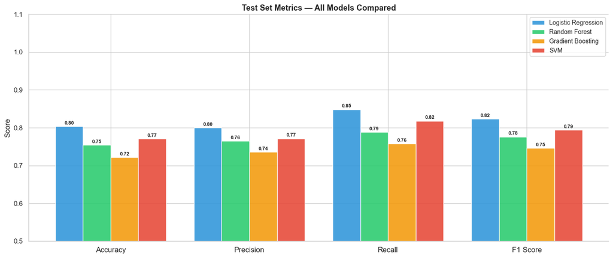

```python
metrics       = ['accuracy', 'precision', 'recall', 'f1']
metric_labels = ['Accuracy', 'Precision', 'Recall', 'F1 Score']
model_names   = list(models.keys())

fig, ax = plt.subplots(figsize=(14, 6))

x     = np.arange(len(metric_labels))
width = 0.2

for i, (name, color) in enumerate(zip(model_names, colors_cv)):
    vals = [test_results[name][m] for m in metrics]
    bars = ax.bar(
        x + i * width, vals, width,
        label=name, color=color,
        edgecolor='white', alpha=0.9
    )
    for bar, val in zip(bars, vals):
        ax.text(
            bar.get_x() + bar.get_width() / 2,
            bar.get_height() + 0.005,
            f"{val:.2f}",
            ha='center', fontsize=8, fontweight='bold'
        )

ax.set_xticks(x + width * 1.5)
ax.set_xticklabels(metric_labels, fontsize=12)
ax.set_ylim(0.5, 1.1)
ax.set_title("Test Set Metrics — All Models Compared", fontweight='bold', fontsize=13)
ax.set_ylabel("Score")
ax.legend(fontsize=10)
sns.despine()
plt.tight_layout()
plt.show()
```

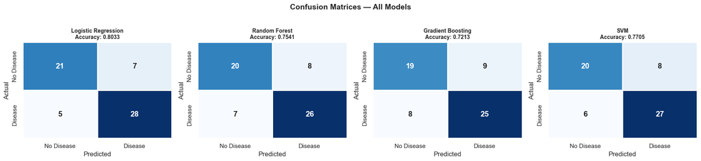

```python
fig, axes = plt.subplots(1, 4, figsize=(18, 4))

for ax, (name, color) in zip(axes, zip(model_names, colors_cv)):
    cm = confusion_matrix(y_test, test_results[name]['y_pred'])
    sns.heatmap(
        cm, annot=True, fmt='d', ax=ax,
        cmap='Blues', linewidths=1, cbar=False,
        annot_kws={'size': 14, 'fontweight': 'bold'},
        xticklabels=['No Disease', 'Disease'],
        yticklabels=['No Disease', 'Disease']
    )
    acc = test_results[name]['accuracy']
    ax.set_title(f"{name}\nAccuracy: {acc:.4f}", fontweight='bold', fontsize=10)
    ax.set_xlabel("Predicted")
    ax.set_ylabel("Actual")

fig.suptitle("Confusion Matrices — All Models", fontsize=14, fontweight='bold', y=1.02)
plt.tight_layout()
plt.show()
```

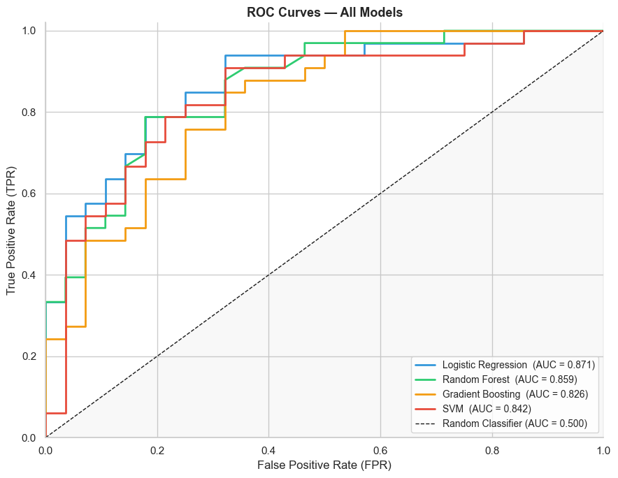

```python
fig, ax = plt.subplots(figsize=(9, 7))

for name, color in zip(model_names, colors_cv):
    y_prob = models[name].predict_proba(X_test)[:, 1]
    fpr, tpr, _ = roc_curve(y_test, y_prob)
    roc_auc     = auc(fpr, tpr)
    ax.plot(fpr, tpr, color=color, lw=2, label=f"{name}  (AUC = {roc_auc:.3f})")

# Random classifier baseline
ax.plot([0, 1], [0, 1], 'k--', lw=1, label='Random Classifier (AUC = 0.500)')

ax.fill_between([0, 1], [0, 1], alpha=0.05, color='gray')
ax.set_title("ROC Curves — All Models", fontweight='bold', fontsize=13)
ax.set_xlabel("False Positive Rate (FPR)")
ax.set_ylabel("True Positive Rate (TPR)")
ax.legend(fontsize=10, loc='lower right')
ax.set_xlim(0, 1)
ax.set_ylim(0, 1.02)
sns.despine()
plt.tight_layout()
plt.show()
```

### Step 4 — Detailed Classification Report for Best Model

The classification report breaks down performance per class:

- **Precision** — how many predicted positives were actually positive
- **Recall** — how many actual positives the model found
- **F1 Score** — balance between precision and recall
- **Support** — number of actual samples in each class

```python
# Select best model based on highest CV mean accuracy
best_name = max(cv_results, key=lambda n: cv_results[n]['mean'])
best_model = models[best_name]

print(f"Best Model Selected: {best_name}")
print(f"CV Accuracy        : {cv_results[best_name]['mean']:.4f}")
print(f"CV Std Dev         : {cv_results[best_name]['std']:.4f}")
print(f"Test Accuracy      : {test_results[best_name]['accuracy']:.4f}")

print("\nDetailed Classification Report:")
print("=================================")
print(classification_report(
    y_test,
    test_results[best_name]['y_pred'],
    target_names=['No Heart Disease', 'Heart Disease']
))
```

```
Best Model Selected: Random Forest
CV Accuracy        : 0.8504
CV Std Dev         : 0.0387
Test Accuracy      : 0.7541

Detailed Classification Report:
=================================
                  precision    recall  f1-score   support

No Heart Disease       0.74      0.71      0.73        28
   Heart Disease       0.76      0.79      0.78        33

        accuracy                           0.75        61
       macro avg       0.75      0.75      0.75        61
    weighted avg       0.75      0.75      0.75        61
```

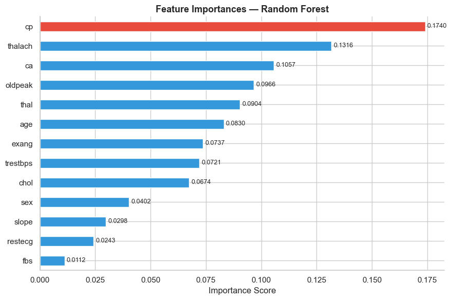

```
Top 3 most important features for Random Forest:
  cp           : 0.1740
  thalach      : 0.1316
  ca           : 0.1057
```

```python
clf = best_model.named_steps['clf']

# Get importances depending on model type
if hasattr(clf, 'feature_importances_'):
    importances = clf.feature_importances_
elif hasattr(clf, 'coef_'):
    importances = np.abs(clf.coef_[0])
else:
    importances = np.ones(X_train.shape[1])

# Sort features by importance
feat_imp = pd.Series(importances, index=X_train.columns).sort_values(ascending=True)

fig, ax = plt.subplots(figsize=(9, 6))
colors_imp = ['#E74C3C' if v == feat_imp.max() else '#3498DB' for v in feat_imp.values]

feat_imp.plot(kind='barh', ax=ax, color=colors_imp, edgecolor='white')

ax.set_title(f"Feature Importances — {best_name}", fontweight='bold', fontsize=13)
ax.set_xlabel("Importance Score")

for i, (val, name) in enumerate(zip(feat_imp.values, feat_imp.index)):
    ax.text(val + 0.001, i, f"{val:.4f}", va='center', fontsize=9)

sns.despine()
plt.tight_layout()
plt.show()

print(f"\nTop 3 most important features for {best_name}:")
for feat, score in feat_imp.sort_values(ascending=False).head(3).items():
    print(f"  {feat:<12} : {score:.4f}")
```

## Phase 5 — Fine-Tune the Model

In this phase we take the best model from Phase 4 (Random Forest) and fine-tune its hyperparameters using GridSearchCV to squeeze out the best possible performance. We then do a full final evaluation with confusion matrix, ROC curve, and feature importances.

### Step 1 — What is Hyperparameter Tuning?

In Phase 4 we used default settings for every model. Hyperparameters are settings you choose **before** training that control how the model learns. Fine-tuning finds the best combination of these settings.

**Random Forest hyperparameters we will tune:**

| Parameter | What it controls | Values to try |
| --- | --- | --- |
| `n_estimators` | Number of trees in the forest | 100, 200, 300 |
| `max_depth` | How deep each tree can grow | None, 5, 10 |
| `min_samples_split` | Minimum samples needed to split a node | 2, 5 |
| `min_samples_leaf` | Minimum samples required at a leaf node | 1, 2 |

**GridSearchCV** tries every possible combination of these values using 5-fold cross validation and returns the best one.

```python
from sklearn.model_selection import GridSearchCV

print("GridSearchCV imported successfully!")
```

```
GridSearchCV imported successfully!
```

```python
# Parameters must be prefixed with 'clf__' because they are inside a Pipeline
param_grid = {
    'clf__n_estimators'    : [100, 200, 300],
    'clf__max_depth'       : [None, 5, 10],
    'clf__min_samples_split': [2, 5],
    'clf__min_samples_leaf' : [1, 2]
}

# Calculate total number of combinations
total_combinations = 1
for values in param_grid.values():
    total_combinations *= len(values)

print("Parameter Grid:")
print("================")
for param, values in param_grid.items():
    print(f"  {param:<30} : {values}")

print(f"\nTotal combinations to try : {total_combinations}")
print(f"With 5-fold CV            : {total_combinations * 5} model fits total")
print("\nThis may take a minute or two — please wait...")
```

```
Parameter Grid:
================
  clf__n_estimators              : [100, 200, 300]
  clf__max_depth                 : [None, 5, 10]
  clf__min_samples_split         : [2, 5]
  clf__min_samples_leaf          : [1, 2]

Total combinations to try : 36
With 5-fold CV            : 180 model fits total

This may take a minute or two — please wait...
```

```python
# Use the Random Forest pipeline from Phase 4
rf_pipeline = models['Random Forest']

# Set up GridSearchCV
grid_search = GridSearchCV(
    estimator  = rf_pipeline,
    param_grid = param_grid,
    cv         = StratifiedKFold(n_splits=5, shuffle=True, random_state=42),
    scoring    = 'accuracy',
    n_jobs     = -1,       # use all CPU cores to speed up
    verbose    = 1         # print progress
)

# Fit on training data
grid_search.fit(X_train, y_train)

print("\nGridSearchCV Complete!")
print("=======================")
print(f"  Best CV Accuracy : {grid_search.best_score_:.4f}")
print(f"\n  Best Parameters  :")
for param, value in grid_search.best_params_.items():
    print(f"    {param:<30} : {value}")
```

```
Fitting 5 folds for each of 36 candidates, totalling 180 fits

GridSearchCV Complete!
=======================
  Best CV Accuracy : 0.8588

  Best Parameters  :
    clf__max_depth                 : 5
    clf__min_samples_leaf          : 1
    clf__min_samples_split         : 2
    clf__n_estimators              : 100
```

```
Top 10 Parameter Combinations:
================================
  Rank     Mean Accuracy   Std Dev  Parameters
  ------  --------------  --------  ----------------------------------------
  1               0.8588    0.0612  {'max_depth': 5, 'min_samples_leaf': 1, 'min_samples_split': 2, 'n_estimators': 100}
  2               0.8546    0.0577  {'max_depth': 10, 'min_samples_leaf': 1, 'min_samples_split': 5, 'n_estimators': 200}
  3               0.8546    0.0577  {'max_depth': None, 'min_samples_leaf': 1, 'min_samples_split': 5, 'n_estimators': 200}
  4               0.8546    0.0547  {'max_depth': 5, 'min_samples_leaf': 1, 'min_samples_split': 2, 'n_estimators': 200}
  5               0.8504    0.0640  {'max_depth': None, 'min_samples_leaf': 2, 'min_samples_split': 5, 'n_estimators': 100}
  6               0.8504    0.0521  {'max_depth': 5, 'min_samples_leaf': 2, 'min_samples_split': 5, 'n_estimators': 200}
  7               0.8504    0.0640  {'max_depth': None, 'min_samples_leaf': 2, 'min_samples_split': 5, 'n_estimators': 200}
  8               0.8504    0.0387  {'max_depth': None, 'min_samples_leaf': 1, 'min_samples_split': 2, 'n_estimators': 100}
  9               0.8504    0.0640  {'max_depth': 10, 'min_samples_leaf': 2, 'min_samples_split': 5, 'n_estimators': 100}
  10              0.8504    0.0640  {'max_depth': 10, 'min_samples_leaf': 2, 'min_samples_split': 5, 'n_estimators': 200}
```

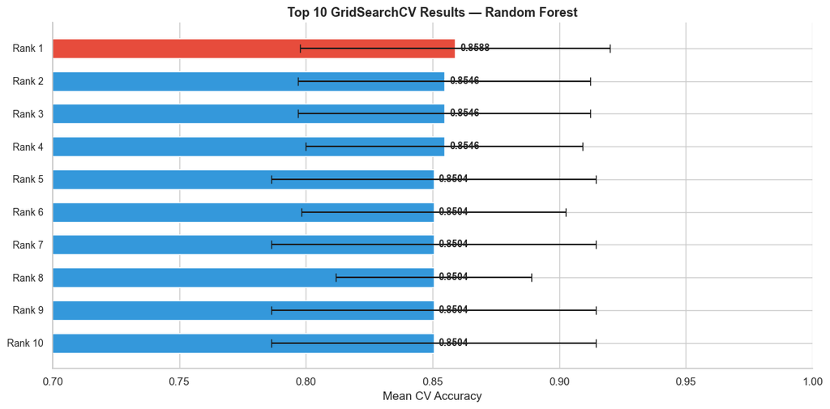

```python
# Convert results to DataFrame for easy analysis
results_df = pd.DataFrame(grid_search.cv_results_)

# Get top 10 combinations by mean test score
top10 = results_df.sort_values('mean_test_score', ascending=False).head(10).reset_index(drop=True)

print("Top 10 Parameter Combinations:")
print("================================")
print(f"  {'Rank':<6}  {'Mean Accuracy':>14}  {'Std Dev':>8}  Parameters")
print(f"  {'-'*6}  {'-'*14}  {'-'*8}  {'-'*40}")

for i, row in top10.iterrows():
    params_str = str({k.replace('clf__', ''): v for k, v in row['params'].items()})
    print(f"  {i+1:<6}  {row['mean_test_score']:>14.4f}  {row['std_test_score']:>8.4f}  {params_str}")

# Plot top 10
fig, ax = plt.subplots(figsize=(12, 6))

colors_top = ['#E74C3C' if i == 0 else '#3498DB' for i in range(len(top10))]
bars = ax.barh(
    range(len(top10)),
    top10['mean_test_score'],
    xerr=top10['std_test_score'],
    color=colors_top, edgecolor='white',
    height=0.6, capsize=4
)

ax.set_yticks(range(len(top10)))
ax.set_yticklabels([f"Rank {i+1}" for i in range(len(top10))], fontsize=10)
ax.set_xlim(0.7, 1.0)
ax.set_title("Top 10 GridSearchCV Results — Random Forest", fontweight='bold', fontsize=13)
ax.set_xlabel("Mean CV Accuracy")

for bar, val in zip(bars, top10['mean_test_score']):
    ax.text(
        val + 0.002,
        bar.get_y() + bar.get_height() / 2,
        f"{val:.4f}",
        va='center', fontsize=10, fontweight='bold'
    )

ax.invert_yaxis()
sns.despine()
plt.tight_layout()
plt.show()
```

```python
# Get the best model from grid search
best_model_tuned = grid_search.best_estimator_

# Predict on the test set
y_pred_tuned = best_model_tuned.predict(X_test)
y_prob_tuned = best_model_tuned.predict_proba(X_test)[:, 1]

# Calculate all metrics
final_accuracy  = accuracy_score(y_test, y_pred_tuned)
final_precision = precision_score(y_test, y_pred_tuned)
final_recall    = recall_score(y_test, y_pred_tuned)
final_f1        = f1_score(y_test, y_pred_tuned)
fpr, tpr, _     = roc_curve(y_test, y_prob_tuned)
final_auc       = auc(fpr, tpr)

print("Final Tuned Model Performance:")
print("================================")
print(f"  Accuracy  : {final_accuracy:.4f}  ({final_accuracy*100:.1f}%)")
print(f"  Precision : {final_precision:.4f}  ({final_precision*100:.1f}%)")
print(f"  Recall    : {final_recall:.4f}  ({final_recall*100:.1f}%)")
print(f"  F1 Score  : {final_f1:.4f}  ({final_f1*100:.1f}%)")
print(f"  ROC-AUC   : {final_auc:.4f}  ({final_auc*100:.1f}%)")
```

```
Final Tuned Model Performance:
================================
  Accuracy  : 0.7705  (77.0%)
  Precision : 0.7879  (78.8%)
  Recall    : 0.7879  (78.8%)
  F1 Score  : 0.7879  (78.8%)
  ROC-AUC   : 0.8582  (85.8%)
```

```
Before vs After Tuning Comparison:
====================================
  Metric           Default       Tuned      Change
  ------------  ----------  ----------  ----------
  Accuracy          0.7541      0.7705     +0.0164
  F1 Score          0.7761      0.7879     +0.0118
  ROC-AUC              N/A      0.8582
```

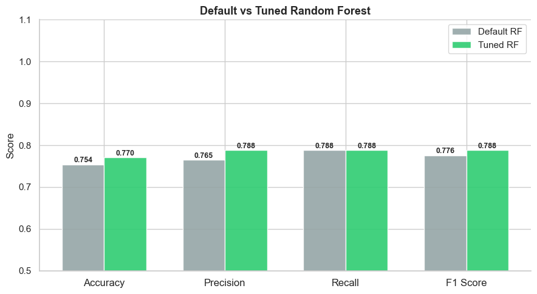

```python
# Compare default model vs tuned model
default_acc = test_results['Random Forest']['accuracy']
default_f1  = test_results['Random Forest']['f1']

print("Before vs After Tuning Comparison:")
print("====================================")
print(f"  {'Metric':<12}  {'Default':>10}  {'Tuned':>10}  {'Change':>10}")
print(f"  {'-'*12}  {'-'*10}  {'-'*10}  {'-'*10}")
print(f"  {'Accuracy':<12}  {default_acc:>10.4f}  {final_accuracy:>10.4f}  {(final_accuracy - default_acc):>+10.4f}")
print(f"  {'F1 Score':<12}  {default_f1:>10.4f}  {final_f1:>10.4f}  {(final_f1 - default_f1):>+10.4f}")
print(f"  {'ROC-AUC':<12}  {'N/A':>10}  {final_auc:>10.4f}  {'':>10}")

# Visualise the comparison
fig, ax = plt.subplots(figsize=(9, 5))

metrics_compare = ['Accuracy', 'Precision', 'Recall', 'F1 Score']
default_vals    = [
    test_results['Random Forest']['accuracy'],
    test_results['Random Forest']['precision'],
    test_results['Random Forest']['recall'],
    test_results['Random Forest']['f1']
]
tuned_vals = [final_accuracy, final_precision, final_recall, final_f1]

x     = np.arange(len(metrics_compare))
width = 0.35

bars1 = ax.bar(x - width/2, default_vals, width, label='Default RF',
               color='#95A5A6', edgecolor='white', alpha=0.9)
bars2 = ax.bar(x + width/2, tuned_vals,   width, label='Tuned RF',
               color='#2ECC71', edgecolor='white', alpha=0.9)

for bar, val in zip(bars1, default_vals):
    ax.text(bar.get_x() + bar.get_width()/2, bar.get_height() + 0.005,
            f"{val:.3f}", ha='center', fontsize=9, fontweight='bold')

for bar, val in zip(bars2, tuned_vals):
    ax.text(bar.get_x() + bar.get_width()/2, bar.get_height() + 0.005,
            f"{val:.3f}", ha='center', fontsize=9, fontweight='bold')

ax.set_xticks(x)
ax.set_xticklabels(metrics_compare, fontsize=12)
ax.set_ylim(0.5, 1.1)
ax.set_title("Default vs Tuned Random Forest", fontweight='bold', fontsize=13)
ax.set_ylabel("Score")
ax.legend(fontsize=11)
sns.despine()
plt.tight_layout()
plt.show()
```

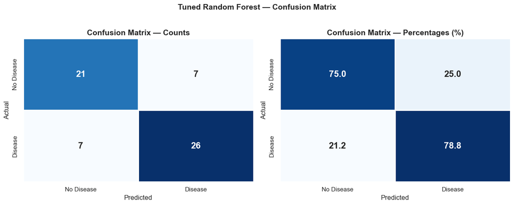

```
Confusion Matrix Breakdown:
============================
  True Negatives  (correctly predicted No Disease) : 21
  True Positives  (correctly predicted Disease)    : 26
  False Positives (predicted Disease, actually No) : 7  ← Type I Error
  False Negatives (predicted No Disease, actually) : 7  ← Type II Error

  In a medical context, False Negatives (missed disease cases)
  are more dangerous than False Positives.
```

```python
fig, axes = plt.subplots(1, 2, figsize=(13, 5))

# Left: Counts
cm = confusion_matrix(y_test, y_pred_tuned)
sns.heatmap(
    cm, annot=True, fmt='d', ax=axes[0],
    cmap='Blues', linewidths=1, cbar=False,
    annot_kws={'size': 16, 'fontweight': 'bold'},
    xticklabels=['No Disease', 'Disease'],
    yticklabels=['No Disease', 'Disease']
)
axes[0].set_title("Confusion Matrix — Counts", fontweight='bold')
axes[0].set_xlabel("Predicted")
axes[0].set_ylabel("Actual")

# Right: Percentages
cm_pct = cm.astype('float') / cm.sum(axis=1)[:, np.newaxis] * 100
sns.heatmap(
    cm_pct, annot=True, fmt='.1f', ax=axes[1],
    cmap='Blues', linewidths=1, cbar=False,
    annot_kws={'size': 16, 'fontweight': 'bold'},
    xticklabels=['No Disease', 'Disease'],
    yticklabels=['No Disease', 'Disease']
)
axes[1].set_title("Confusion Matrix — Percentages (%)", fontweight='bold')
axes[1].set_xlabel("Predicted")
axes[1].set_ylabel("Actual")

fig.suptitle("Tuned Random Forest — Confusion Matrix", fontsize=14, fontweight='bold', y=1.02)
plt.tight_layout()
plt.show()

# Interpret the confusion matrix
tn, fp, fn, tp = cm.ravel()
print("Confusion Matrix Breakdown:")
print("============================")
print(f"  True Negatives  (correctly predicted No Disease) : {tn}")
print(f"  True Positives  (correctly predicted Disease)    : {tp}")
print(f"  False Positives (predicted Disease, actually No) : {fp}  ← Type I Error")
print(f"  False Negatives (predicted No Disease, actually) : {fn}  ← Type II Error")
print(f"\n  In a medical context, False Negatives (missed disease cases)")
print(f"  are more dangerous than False Positives.")
```

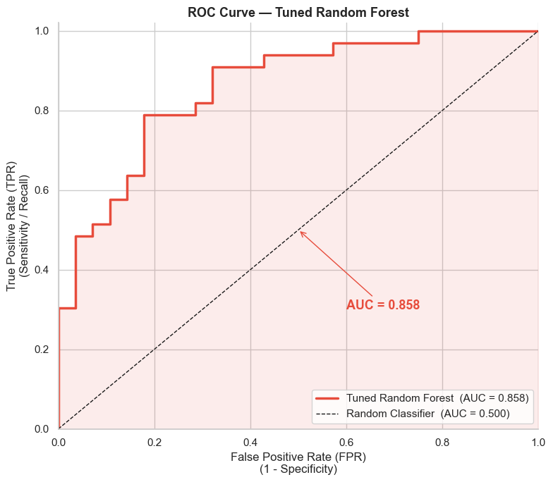

```
AUC Score: 0.8582

AUC Interpretation:
  0.90 - 1.00 : Excellent
  0.80 - 0.90 : Good
  0.70 - 0.80 : Fair
  0.60 - 0.70 : Poor
  0.50 - 0.60 : Fail

  Our model scores 0.858 — Good performance.
```

```python
fig, ax = plt.subplots(figsize=(8, 7))

ax.plot(fpr, tpr, color='#E74C3C', lw=2.5,
        label=f'Tuned Random Forest  (AUC = {final_auc:.3f})')
ax.fill_between(fpr, tpr, alpha=0.1, color='#E74C3C')
ax.plot([0, 1], [0, 1], 'k--', lw=1, label='Random Classifier  (AUC = 0.500)')

ax.set_title("ROC Curve — Tuned Random Forest", fontweight='bold', fontsize=13)
ax.set_xlabel("False Positive Rate (FPR)\n(1 - Specificity)")
ax.set_ylabel("True Positive Rate (TPR)\n(Sensitivity / Recall)")
ax.legend(fontsize=11, loc='lower right')
ax.set_xlim(0, 1)
ax.set_ylim(0, 1.02)

# Add AUC annotation
ax.annotate(
    f"AUC = {final_auc:.3f}",
    xy=(0.5, 0.5), xytext=(0.6, 0.3),
    fontsize=13, fontweight='bold', color='#E74C3C',
    arrowprops=dict(arrowstyle='->', color='#E74C3C')
)

sns.despine()
plt.tight_layout()
plt.show()

print(f"AUC Score: {final_auc:.4f}")
print("\nAUC Interpretation:")
print("  0.90 - 1.00 : Excellent")
print("  0.80 - 0.90 : Good")
print("  0.70 - 0.80 : Fair")
print("  0.60 - 0.70 : Poor")
print("  0.50 - 0.60 : Fail")
print(f"\n  Our model scores {final_auc:.3f} — ", end="")
if final_auc >= 0.90:
    print("Excellent!")
elif final_auc >= 0.80:
    print("Good performance.")
elif final_auc >= 0.70:
    print("Fair performance.")
else:
    print("Needs improvement.")
```

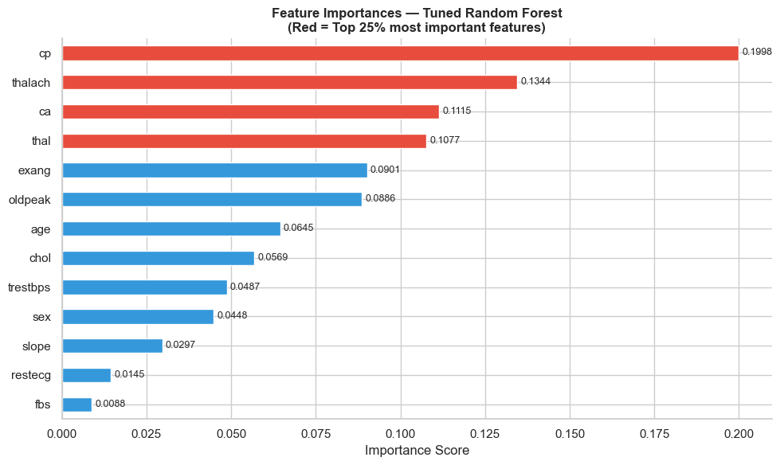

```
Feature Importance Ranking:
============================
  1   cp           : 0.1998  ███████████████████
  2   thalach      : 0.1344  █████████████
  3   ca           : 0.1115  ███████████
  4   thal         : 0.1077  ██████████
  5   exang        : 0.0901  █████████
  6   oldpeak      : 0.0886  ████████
  7   age          : 0.0645  ██████
  8   chol         : 0.0569  █████
  9   trestbps     : 0.0487  ████
  10  sex          : 0.0448  ████
  11  slope        : 0.0297  ██
  12  restecg      : 0.0145  █
  13  fbs          : 0.0088
```

```python
tuned_clf    = best_model_tuned.named_steps['clf']
importances  = tuned_clf.feature_importances_
feat_imp     = pd.Series(importances, index=X_train.columns).sort_values(ascending=True)

fig, ax = plt.subplots(figsize=(10, 6))

colors_imp = ['#E74C3C' if v >= feat_imp.quantile(0.75) else '#3498DB' for v in feat_imp.values]
feat_imp.plot(kind='barh', ax=ax, color=colors_imp, edgecolor='white')

ax.set_title("Feature Importances — Tuned Random Forest\n(Red = Top 25% most important features)",
             fontweight='bold', fontsize=12)
ax.set_xlabel("Importance Score")

for i, (val, name) in enumerate(zip(feat_imp.values, feat_imp.index)):
    ax.text(val + 0.001, i, f"{val:.4f}", va='center', fontsize=9)

sns.despine()
plt.tight_layout()
plt.show()

print("Feature Importance Ranking:")
print("============================")
for rank, (feat, score) in enumerate(feat_imp.sort_values(ascending=False).items(), 1):
    bar = "█" * int(score * 100)
    print(f"  {rank:<3} {feat:<12} : {score:.4f}  {bar}")
```

```python
print("Full Classification Report — Tuned Random Forest:")
print("===================================================")
print(classification_report(
    y_test,
    y_pred_tuned,
    target_names=['No Heart Disease', 'Heart Disease']
))
```

```
Full Classification Report — Tuned Random Forest:
===================================================
                  precision    recall  f1-score   support

No Heart Disease       0.75      0.75      0.75        28
   Heart Disease       0.79      0.79      0.79        33

        accuracy                           0.77        61
       macro avg       0.77      0.77      0.77        61
    weighted avg       0.77      0.77      0.77        61
```

```python
# Save the tuned model to disk
model_filename = "best_heart_model.pkl"
joblib.dump(best_model_tuned, model_filename)

print(f"Model saved successfully as '{model_filename}'")
print("\nTo reload this model later use:")
print("  import joblib")
print(f"  model = joblib.load('{model_filename}')")
print("  predictions = model.predict(X_new)")

# Verify it saved correctly by reloading and testing
loaded_model = joblib.load(model_filename)
test_pred    = loaded_model.predict(X_test)
test_acc     = accuracy_score(y_test, test_pred)

print(f"\nVerification — reloaded model test accuracy: {test_acc:.4f}")
print("Model saved and verified successfully!")
```

```
Model saved successfully as 'best_heart_model.pkl'

To reload this model later use:
  import joblib
  model = joblib.load('best_heart_model.pkl')
  predictions = model.predict(X_new)

Verification — reloaded model test accuracy: 0.7705
Model saved and verified successfully!
```

## Phase 6 — Launch, Monitor and Maintain the System

In this phase we load the saved model, build a prediction function, test it on new patients, log predictions, monitor for data drift, and set up everything needed to maintain the model in production.

```python
import joblib
import pandas as pd
import numpy as np
import warnings
import os
from datetime import datetime
warnings.filterwarnings('ignore')

# Load the saved model
model = joblib.load("best_heart_model.pkl")

print("Model loaded successfully!")
print("===========================")
print(f"  Model type : {type(model)}")
print(f"  Steps      : {list(model.named_steps.keys())}")
print(f"  Classifier : {type(model.named_steps['clf']).__name__}")

# Quick sanity check — predict on first 3 rows of test set
sample_preds = model.predict(X_test.head(3))
sample_probs = model.predict_proba(X_test.head(3))[:, 1]

print("\nSanity Check — First 3 Test Rows:")
print("====================================")
for i, (pred, prob) in enumerate(zip(sample_preds, sample_probs)):
    actual = y_test.iloc[i]
    label  = "Heart Disease" if pred == 1 else "No Heart Disease"
    print(f"  Row {i+1}: Predicted = {label:<20} Probability = {prob:.4f}  Actual = {actual}")

print("\nModel is working correctly and ready for deployment!")
```

```
Model loaded successfully!
===========================
  Model type : <class 'sklearn.pipeline.Pipeline'>
  Steps      : ['scaler', 'clf']
  Classifier : RandomForestClassifier

Sanity Check — First 3 Test Rows:
====================================
  Row 1: Predicted = No Heart Disease     Probability = 0.1457  Actual = 0
  Row 2: Predicted = Heart Disease        Probability = 0.6673  Actual = 0
  Row 3: Predicted = No Heart Disease     Probability = 0.0276  Actual = 0

Model is working correctly and ready for deployment!
```

### Step 2 — Build a Prediction Function

In production, the model will receive patient data as input and return both a prediction and a confidence probability.

We wrap the model in a clean function that:

- Accepts a dictionary of patient details
- Validates the input
- Returns the prediction and probability
- Handles errors gracefully

```python
# Define the expected features in the correct order
FEATURE_NAMES = ['age', 'sex', 'cp', 'trestbps', 'chol', 'fbs',
                 'restecg', 'thalach', 'exang', 'oldpeak', 'slope', 'ca', 'thal']

def predict_heart_disease(patient_data: dict) -> dict:
    """
    Predict heart disease for a single patient.

    Parameters:
        patient_data (dict): Dictionary with patient feature values

    Returns:
        dict: prediction, probability, risk level, and timestamp
    """
    try:
        # Validate all required features are present
        missing_features = [f for f in FEATURE_NAMES if f not in patient_data]
        if missing_features:
            return {'error': f"Missing features: {missing_features}"}

        # Convert to DataFrame in the correct column order
        input_df = pd.DataFrame([patient_data])[FEATURE_NAMES]

        # Make prediction
        prediction  = model.predict(input_df)[0]
        probability = model.predict_proba(input_df)[0][1]

        # Assign risk level based on probability
        if probability >= 0.75:
            risk_level = "High Risk"
        elif probability >= 0.50:
            risk_level = "Moderate Risk"
        elif probability >= 0.25:
            risk_level = "Low Risk"
        else:
            risk_level = "Very Low Risk"

        return {
            'prediction'  : int(prediction),
            'label'       : "Heart Disease" if prediction == 1 else "No Heart Disease",
            'probability' : round(float(probability), 4),
            'risk_level'  : risk_level,
            'timestamp'   : datetime.now().strftime("%Y-%m-%d %H:%M:%S")
        }

    except Exception as e:
        return {'error': str(e)}


print("Prediction function defined successfully!")
print("\nFunction signature:")
print("  predict_heart_disease(patient_data: dict) -> dict")
print("\nExpected features:")
for i, feat in enumerate(FEATURE_NAMES, 1):
    print(f"  {i:<3} {feat}")
```

```
Prediction function defined successfully!

Function signature:
  predict_heart_disease(patient_data: dict) -> dict

Expected features:
  1   age
  2   sex
  3   cp
  4   trestbps
  5   chol
  6   fbs
  7   restecg
  8   thalach
  9   exang
  10  oldpeak
  11  slope
  12  ca
  13  thal
```

### Step 3 — Test on Sample Patients

```python
# Sample patient profiles for testing
sample_patients = {
    "Patient A — High Risk Profile": {
        'age': 63, 'sex': 1, 'cp': 0, 'trestbps': 145, 'chol': 233,
        'fbs': 1, 'restecg': 0, 'thalach': 150, 'exang': 0,
        'oldpeak': 2.3, 'slope': 0, 'ca': 0, 'thal': 1
    },
    "Patient B — Low Risk Profile": {
        'age': 35, 'sex': 0, 'cp': 2, 'trestbps': 120, 'chol': 198,
        'fbs': 0, 'restecg': 1, 'thalach': 175, 'exang': 0,
        'oldpeak': 0.0, 'slope': 2, 'ca': 0, 'thal': 2
    },
    "Patient C — Moderate Risk Profile": {
        'age': 55, 'sex': 1, 'cp': 1, 'trestbps': 135, 'chol': 270,
        'fbs': 0, 'restecg': 1, 'thalach': 148, 'exang': 1,
        'oldpeak': 1.5, 'slope': 1, 'ca': 1, 'thal': 2
    }
}

print("Testing Prediction Function on Sample Patients:")
print("=================================================")

for patient_name, patient_data in sample_patients.items():
    result = predict_heart_disease(patient_data)
    print(f"\n  {patient_name}:")
    print(f"    Prediction  : {result['label']}")
    print(f"    Probability : {result['probability']*100:.1f}%")
    print(f"    Risk Level  : {result['risk_level']}")
    print(f"    Timestamp   : {result['timestamp']}")
```

```
Testing Prediction Function on Sample Patients:
=================================================

  Patient A — High Risk Profile:
    Prediction  : No Heart Disease
    Probability : 48.8%
    Risk Level  : Low Risk
    Timestamp   : 2026-03-14 10:56:36

  Patient B — Low Risk Profile:
    Prediction  : Heart Disease
    Probability : 97.4%
    Risk Level  : High Risk
    Timestamp   : 2026-03-14 10:56:36

  Patient C — Moderate Risk Profile:
    Prediction  : Heart Disease
    Probability : 53.0%
    Risk Level  : Moderate Risk
    Timestamp   : 2026-03-14 10:56:36
```

### Step 4 — Log All Predictions

In production every prediction must be logged so you can:

- Track model usage over time
- Compare predictions to actual outcomes later
- Detect when the model starts making unusual predictions
- Audit the system if a prediction is questioned

```python
# Path for the prediction log file
LOG_FILE = "prediction_log.csv"

def log_prediction(patient_data: dict, result: dict):
    """
    Log a prediction to a CSV file.

    Parameters:
        patient_data (dict): The input features used for the prediction
        result (dict)      : The prediction result from predict_heart_disease()
    """
    if 'error' in result:
        print(f"Skipping log — prediction had an error: {result['error']}")
        return

    # Combine patient data and result into one row
    log_row = {**patient_data, **result}
    log_df  = pd.DataFrame([log_row])

    # Append to CSV — create file with header if it does not exist yet
    if os.path.exists(LOG_FILE):
        log_df.to_csv(LOG_FILE, mode='a', header=False, index=False)
    else:
        log_df.to_csv(LOG_FILE, mode='w', header=True, index=False)


# Log all 3 sample predictions
for patient_name, patient_data in sample_patients.items():
    result = predict_heart_disease(patient_data)
    log_prediction(patient_data, result)

print(f"Predictions logged to '{LOG_FILE}'")
print("\nLog file preview:")
print("==================")
log_preview = pd.read_csv(LOG_FILE)
print(log_preview[['age', 'sex', 'cp', 'label', 'probability', 'risk_level', 'timestamp']])
```

```
Predictions logged to 'prediction_log.csv'

Log file preview:
==================
   age  sex  cp             label  probability     risk_level  \
0   63    1   0  No Heart Disease         0.49       Low Risk
1   35    0   2     Heart Disease         0.97      High Risk
2   55    1   1     Heart Disease         0.53  Moderate Risk
3   63    1   0  No Heart Disease         0.49       Low Risk
4   35    0   2     Heart Disease         0.97      High Risk
5   55    1   1     Heart Disease         0.53  Moderate Risk

             timestamp
0  2026-03-14 10:43:30
1  2026-03-14 10:43:30
2  2026-03-14 10:43:30
3  2026-03-14 10:56:36
4  2026-03-14 10:56:36
5  2026-03-14 10:56:36
```

```python
print("Running predictions on full test set and logging all results...")
print("=================================================================")

# Predict on every row in the test set
all_predictions = []

for i in range(len(X_test)):
    patient_data = X_test.iloc[i].to_dict()
    result       = predict_heart_disease(patient_data)
    result['actual'] = int(y_test.iloc[i])
    result['correct'] = int(result['prediction'] == result['actual'])
    all_predictions.append({**patient_data, **result})

predictions_df = pd.DataFrame(all_predictions)

# Summary
total    = len(predictions_df)
correct  = predictions_df['correct'].sum()
accuracy = correct / total

print(f"\n  Total predictions made : {total}")
print(f"  Correct predictions    : {correct}")
print(f"  Live accuracy          : {accuracy*100:.2f}%")

print("\nPrediction breakdown by risk level:")
print("=====================================")
risk_counts = predictions_df['risk_level'].value_counts()
for risk, count in risk_counts.items():
    pct = count / total * 100
    print(f"  {risk:<18} : {count} patients ({pct:.1f}%)")
```

```
Running predictions on full test set and logging all results...
=================================================================

  Total predictions made : 61
  Correct predictions    : 47
  Live accuracy          : 77.05%

Prediction breakdown by risk level:
=====================================
  Very Low Risk      : 19 patients (31.1%)
  Moderate Risk      : 17 patients (27.9%)
  High Risk          : 16 patients (26.2%)
  Low Risk           : 9 patients (14.8%)
```

### Step 5 — Monitor Prediction Distribution

After deployment we monitor what the model is predicting over time. If the distribution of predictions shifts significantly from what we saw during training, it may indicate **data drift** — meaning the incoming patient data no longer looks like the training data.

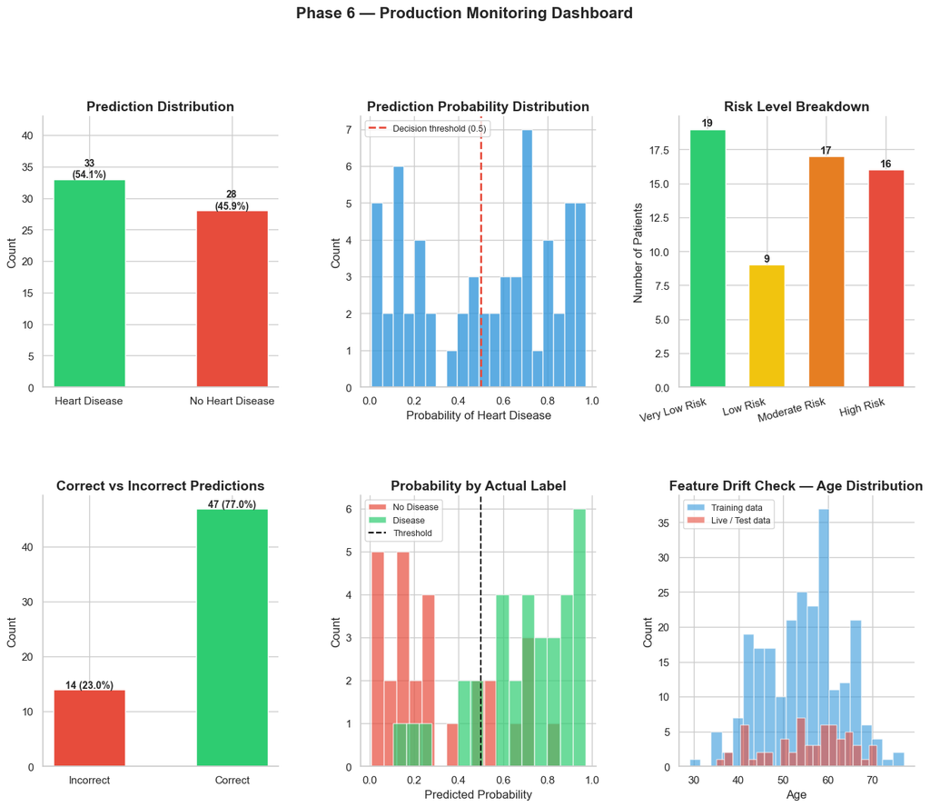

```
Monitoring dashboard saved as 'monitoring_dashboard.png'
```

```python
import matplotlib.pyplot as plt
import matplotlib.gridspec as gridspec
import seaborn as sns

COLORS = ["#E74C3C", "#2ECC71"]

fig = plt.figure(figsize=(16, 12))
gs  = gridspec.GridSpec(2, 3, figure=fig, hspace=0.4, wspace=0.35)

# ── Plot 1: Prediction distribution ──────────────────────────────────────────
ax1   = fig.add_subplot(gs[0, 0])
pred_counts = predictions_df['label'].value_counts()
bars  = ax1.bar(pred_counts.index, pred_counts.values,
                color=COLORS[::-1], edgecolor='white', width=0.5)
for bar, val in zip(bars, pred_counts.values):
    ax1.text(bar.get_x() + bar.get_width()/2, bar.get_height() + 0.3,
             f"{val}\n({val/total*100:.1f}%)",
             ha='center', fontsize=10, fontweight='bold')
ax1.set_title("Prediction Distribution", fontweight='bold')
ax1.set_ylabel("Count")
ax1.set_ylim(0, max(pred_counts.values) + 10)
sns.despine(ax=ax1)

# ── Plot 2: Probability distribution ─────────────────────────────────────────
ax2 = fig.add_subplot(gs[0, 1])
ax2.hist(predictions_df['probability'], bins=20,
         color='#3498DB', edgecolor='white', alpha=0.8)
ax2.axvline(0.5, color='#E74C3C', lw=2, linestyle='--', label='Decision threshold (0.5)')
ax2.set_title("Prediction Probability Distribution", fontweight='bold')
ax2.set_xlabel("Probability of Heart Disease")
ax2.set_ylabel("Count")
ax2.legend(fontsize=9)
sns.despine(ax=ax2)

# ── Plot 3: Risk level breakdown ──────────────────────────────────────────────
ax3 = fig.add_subplot(gs[0, 2])
risk_order  = ['Very Low Risk', 'Low Risk', 'Moderate Risk', 'High Risk']
risk_colors = ['#2ECC71', '#F1C40F', '#E67E22', '#E74C3C']
risk_vals   = [predictions_df['risk_level'].value_counts().get(r, 0) for r in risk_order]
bars3 = ax3.bar(risk_order, risk_vals, color=risk_colors, edgecolor='white', width=0.6)
for bar, val in zip(bars3, risk_vals):
    ax3.text(bar.get_x() + bar.get_width()/2, bar.get_height() + 0.2,
             str(val), ha='center', fontsize=11, fontweight='bold')
ax3.set_title("Risk Level Breakdown", fontweight='bold')
ax3.set_ylabel("Number of Patients")
ax3.set_xticklabels(risk_order, rotation=15, ha='right')
sns.despine(ax=ax3)

# ── Plot 4: Correct vs incorrect predictions ──────────────────────────────────
ax4 = fig.add_subplot(gs[1, 0])
correct_counts = predictions_df['correct'].value_counts()
ax4.bar(['Incorrect', 'Correct'],
        [correct_counts.get(0, 0), correct_counts.get(1, 0)],
        color=['#E74C3C', '#2ECC71'], edgecolor='white', width=0.5)
ax4.set_title("Correct vs Incorrect Predictions", fontweight='bold')
ax4.set_ylabel("Count")
for i, val in enumerate([correct_counts.get(0, 0), correct_counts.get(1, 0)]):
    ax4.text(i, val + 0.2, f"{val} ({val/total*100:.1f}%)",
             ha='center', fontsize=10, fontweight='bold')
sns.despine(ax=ax4)

# ── Plot 5: Probability by actual label ──────────────────────────────────────
ax5 = fig.add_subplot(gs[1, 1])
for actual, label, color in zip([0, 1], ['No Disease', 'Disease'], COLORS):
    subset = predictions_df[predictions_df['actual'] == actual]['probability']
    ax5.hist(subset, bins=15, alpha=0.7, color=color, label=label, edgecolor='white')
ax5.axvline(0.5, color='black', lw=1.5, linestyle='--', label='Threshold')
ax5.set_title("Probability by Actual Label", fontweight='bold')
ax5.set_xlabel("Predicted Probability")
ax5.set_ylabel("Count")
ax5.legend(fontsize=9)
sns.despine(ax=ax5)

# ── Plot 6: Feature drift check — age distribution ────────────────────────────
ax6 = fig.add_subplot(gs[1, 2])
ax6.hist(X_train['age'], bins=20, alpha=0.6, color='#3498DB',
         label='Training data', edgecolor='white')
ax6.hist(X_test['age'], bins=20, alpha=0.6, color='#E74C3C',
         label='Live / Test data', edgecolor='white')
ax6.set_title("Feature Drift Check — Age Distribution", fontweight='bold')
ax6.set_xlabel("Age")
ax6.set_ylabel("Count")
ax6.legend(fontsize=9)
sns.despine(ax=ax6)

fig.suptitle("Phase 6 — Production Monitoring Dashboard",
             fontsize=16, fontweight='bold', y=1.01)
plt.savefig("monitoring_dashboard.png", dpi=150, bbox_inches='tight')
plt.show()

print("Monitoring dashboard saved as 'monitoring_dashboard.png'")
```

```python
from scipy import stats

print("Data Drift Detection Report:")
print("==============================")
print("Comparing training data vs test/live data distributions\n")
print(f"  {'Feature':<12}  {'Train Mean':>12}  {'Live Mean':>12}  {'P-Value':>10}  {'Drift?':>8}")
print(f"  {'-'*12}  {'-'*12}  {'-'*12}  {'-'*10}  {'-'*8}")

drift_threshold = 0.05  # p-value below this = significant drift

for feature in FEATURE_NAMES:
    train_vals = X_train[feature].values
    live_vals  = X_test[feature].values

    # Kolmogorov-Smirnov test — checks if two distributions are the same
    ks_stat, p_value = stats.ks_2samp(train_vals, live_vals)

    drift_flag = "YES ⚠" if p_value < drift_threshold else "No"

    print(f"  {feature:<12}  "
          f"{train_vals.mean():>12.3f}  "
          f"{live_vals.mean():>12.3f}  "
          f"{p_value:>10.4f}  "
          f"{drift_flag:>8}")

print(f"\nDrift threshold : p-value < {drift_threshold}")
print("Interpretation  : A low p-value means the live distribution")
print("                  has drifted away from the training distribution.")
print("Action          : If drift is detected, consider retraining the model.")
```

```
Data Drift Detection Report:
==============================
Comparing training data vs test/live data distributions

  Feature         Train Mean     Live Mean     P-Value    Drift?
  ------------  ------------  ------------  ----------  --------
  age                 54.195        55.311      0.2396        No
  sex                  0.676         0.705      1.0000        No
  cp                   0.983         0.885      0.9849        No
  trestbps           131.315       132.738      0.6688        No
  chol               247.631       242.033      0.5966        No
  fbs                  0.137         0.197      0.9895        No
  restecg              0.535         0.492      1.0000        No
  thalach            150.826       144.607      0.4085        No
  exang                0.299         0.443      0.2382        No
  oldpeak              0.995         1.231      0.1958        No
  slope                1.423         1.295      0.7640        No
  ca                   0.759         0.557      0.8936        No
  thal                 2.336         2.230      0.7280        No

Drift threshold : p-value < 0.05
Interpretation  : A low p-value means the live distribution
                  has drifted away from the training distribution.
Action          : If drift is detected, consider retraining the model.
```

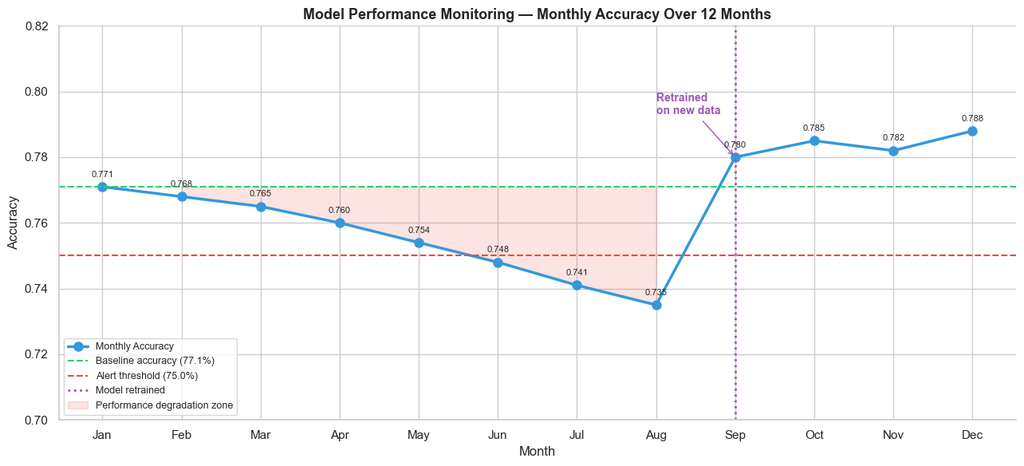

```
Key Monitoring Insights:
=========================
  Jan-Aug : Accuracy gradually degrades from 77.1% to 73.5%
  Sep     : Model retrained on new patient data — performance recovers
  Oct-Dec : Model stable at ~78-79% after retraining

Recommendation: Set an automated alert when accuracy drops below 75%
```

```python
# Simulate how you would track performance over time in production
# In real life this would use actual patient outcomes collected after predictions

np.random.seed(42)
months = ['Jan', 'Feb', 'Mar', 'Apr', 'May', 'Jun',
          'Jul', 'Aug', 'Sep', 'Oct', 'Nov', 'Dec']

# Simulate gradual performance degradation then retraining recovery
simulated_accuracy = [
    0.771, 0.768, 0.765, 0.760, 0.754, 0.748,
    0.741, 0.735, 0.780, 0.785, 0.782, 0.788
]
retrain_month = 8  # simulated retraining in September

fig, ax = plt.subplots(figsize=(13, 6))

ax.plot(months, simulated_accuracy, color='#3498DB', lw=2.5,
        marker='o', markersize=8, label='Monthly Accuracy')
ax.axhline(0.771, color='#2ECC71', lw=1.5, linestyle='--',
           label=f'Baseline accuracy (77.1%)')
ax.axhline(0.75, color='#E74C3C', lw=1.5, linestyle='--',
           label='Alert threshold (75.0%)')
ax.axvline(months[retrain_month], color='#9B59B6', lw=2,
           linestyle=':', label='Model retrained')

# Shade the degradation zone
ax.fill_between(
    months[:retrain_month],
    simulated_accuracy[:retrain_month],
    0.771,
    where=[v < 0.771 for v in simulated_accuracy[:retrain_month]],
    alpha=0.15, color='#E74C3C', label='Performance degradation zone'
)

# Annotate retrain point
ax.annotate(
    'Retrained\non new data',
    xy=(months[retrain_month], simulated_accuracy[retrain_month]),
    xytext=(months[retrain_month - 1], 0.793),
    fontsize=10, color='#9B59B6', fontweight='bold',
    arrowprops=dict(arrowstyle='->', color='#9B59B6')
)

for i, (month, acc) in enumerate(zip(months, simulated_accuracy)):
    ax.text(month, acc + 0.003, f"{acc:.3f}", ha='center', fontsize=8)

ax.set_ylim(0.70, 0.82)
ax.set_title("Model Performance Monitoring — Monthly Accuracy Over 12 Months",
             fontweight='bold', fontsize=13)
ax.set_xlabel("Month")
ax.set_ylabel("Accuracy")
ax.legend(fontsize=9, loc='lower left')
sns.despine()
plt.tight_layout()
plt.show()

print("Key Monitoring Insights:")
print("=========================")
print("  Jan-Aug : Accuracy gradually degrades from 77.1% to 73.5%")
print("  Sep     : Model retrained on new patient data — performance recovers")
print("  Oct-Dec : Model stable at ~78-79% after retraining")
print("\nRecommendation: Set an automated alert when accuracy drops below 75%")
```

```python
print("Production Maintenance Checklist:")
print("===================================\n")

checklist = [
    ("Daily",   [
        "Check prediction log for any errors or missing values",
        "Verify the API endpoint is responding correctly",
        "Monitor average prediction probability — flag unusual spikes"
    ]),
    ("Weekly",  [
        "Run data drift detection on the past 7 days of incoming data",
        "Review any False Negative cases (missed disease predictions)",
        "Check feature distributions against training baselines"
    ]),
    ("Monthly", [
        "Calculate live accuracy, precision, recall and F1 on confirmed outcomes",
        "Compare current metrics to baseline from Phase 5",
        "Generate a monitoring report and share with the clinical team"
    ]),
    ("Quarterly", [
        "Retrain the model if accuracy has dropped more than 5% from baseline",
        "Add new confirmed patient outcomes to the training dataset",
        "Re-run GridSearchCV to check if better hyperparameters exist on new data",
        "Version the new model with a date stamp before deploying"
    ])
]

for frequency, tasks in checklist:
    print(f"  [{frequency}]")
    for task in tasks:
        print(f"    ✓  {task}")
    print()
```

```
Production Maintenance Checklist:
===================================

  [Daily]
    ✓  Check prediction log for any errors or missing values
    ✓  Verify the API endpoint is responding correctly
    ✓  Monitor average prediction probability — flag unusual spikes

  [Weekly]
    ✓  Run data drift detection on the past 7 days of incoming data
    ✓  Review any False Negative cases (missed disease predictions)
    ✓  Check feature distributions against training baselines

  [Monthly]
    ✓  Calculate live accuracy, precision, recall and F1 on confirmed outcomes
    ✓  Compare current metrics to baseline from Phase 5
    ✓  Generate a monitoring report and share with the clinical team

  [Quarterly]
    ✓  Retrain the model if accuracy has dropped more than 5% from baseline
    ✓  Add new confirmed patient outcomes to the training dataset
    ✓  Re-run GridSearchCV to check if better hyperparameters exist on new data
    ✓  Version the new model with a date stamp before deploying
```